# New Guinea

AntWiki: The Ants --- Online

New Guinea

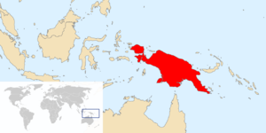

Location

[Region](http://en.wikipedia.org/wiki/United_Nations_geoscheme)

Oceania

[Subregion](http://en.wikipedia.org/wiki/United_Nations_geoscheme)

Melanesia

BioRegion

[Indo-Australian Region](https://www.antwiki.org/wiki/Category:Indo-Australian_Region)

[Diversity](https://www.antwiki.org/wiki/Diversity_by_Country)

Subfamilies

10

Genera

98

Endemic Genera

1

% Endemic Genera

1.0%

Species/Subspecies

894

Endemic Species

533

% Endemic Species

59.6%

Introduced Species

1

Cheklist of ants described and recorded from New Guinea and associated islands. Compiled by M. Janda, G. Alpert, M. Borowiec, P. Klimes, E. M. Sarnat, B. Guenard and S. Shattuck. The large island of New Guinea (the second largest island in the world) includes Indonesia (Western New Guinea) and Papua New Guinea (PNG). This checklist includes records from following areas of New Guinea region: New Guinea island; New Britain; New Ireland; Manus; Bismarck archipelago islands; Aru; d'Entrecasteaux islands; Lousiade archipelago; Waigeo; Misool.

This work was supported by Marie Curie Fellowship 'Ant Biodiversity' (PIOF-GA-2009-254448) and by Czech Science Foundation (P505/12/2467).

website: http://www.newguineants.org

## *Acropyga*

- *[Acropyga acutiventris](https://www.antwiki.org/wiki/Acropyga_acutiventris)* Roger 1862
- *[Acropyga ambigua](https://www.antwiki.org/wiki/Acropyga_ambigua)* Emery 1922
- *[Acropyga major](https://www.antwiki.org/wiki/Acropyga_major)* Donisthorpe 1949
- *[Acropyga oceanica](https://www.antwiki.org/wiki/Acropyga_oceanica)* Emery 1900
- *[Acropyga pallida](https://www.antwiki.org/wiki/Acropyga_pallida)* Donisthorpe 1938

## *Adelomyrmex*

- *[Adelomyrmex biroi](https://www.antwiki.org/wiki/Adelomyrmex_biroi)* Emery 1897

## *Aenictus*

- *[Aenictus aratus](https://www.antwiki.org/wiki/Aenictus_aratus)* Forel 1900
- *[Aenictus chapmani](https://www.antwiki.org/wiki/Aenictus_chapmani)* Wilson 1964
- *[Aenictus currax](https://www.antwiki.org/wiki/Aenictus_currax)* Emery 1900
- *[Aenictus exilis](https://www.antwiki.org/wiki/Aenictus_exilis)* Wilson 1964
- *[Aenictus huonicus](https://www.antwiki.org/wiki/Aenictus_huonicus)* Wilson 1964
- *[Aenictus mocsaryi](https://www.antwiki.org/wiki/Aenictus_mocsaryi)* Emery 1901
- *[Aenictus nesiotis](https://www.antwiki.org/wiki/Aenictus_nesiotis)* Wheeler & Chapman 1930
- *[Aenictus nganduensis](https://www.antwiki.org/wiki/Aenictus_nganduensis)* Wilson 1964
- *[Aenictus obscurus](https://www.antwiki.org/wiki/Aenictus_obscurus)* Smith F. 1865
- *[Aenictus orientalis](https://www.antwiki.org/wiki/Aenictus_orientalis)* Shattuck 2008
- *[Aenictus philiporum](https://www.antwiki.org/wiki/Aenictus_philiporum)* Wilson 1964
- *[Aenictus schneirlai](https://www.antwiki.org/wiki/Aenictus_schneirlai)* Wilson 1964

## *Amblyopone*

- *[Amblyopone australis](https://www.antwiki.org/wiki/Amblyopone_australis)* Erichson 1842

## *Ancyridris*

- *[Ancyridris polyrhachioides](https://www.antwiki.org/wiki/Ancyridris_polyrhachioides)* Wheeler W. M. 1935
- *[Ancyridris rupicapra](https://www.antwiki.org/wiki/Ancyridris_rupicapra)* Stitz 1938

## *Anochetus*

- *[Anochetus cato](https://www.antwiki.org/wiki/Anochetus_cato)* Forel 1901
- *[Anochetus chirichinii](https://www.antwiki.org/wiki/Anochetus_chirichinii)* Emery 1897
- *[Anochetus filicornis](https://www.antwiki.org/wiki/Anochetus_filicornis)* Wheeler W. M. 1929
- *[Anochetus fricatus](https://www.antwiki.org/wiki/Anochetus_fricatus)* Wilson 1959
- *[Anochetus graeffei](https://www.antwiki.org/wiki/Anochetus_graeffei)* Mayr 1870
- *[Anochetus isolatus](https://www.antwiki.org/wiki/Anochetus_isolatus)* Mann 1919
- *[Anochetus peracer](https://www.antwiki.org/wiki/Anochetus_peracer)* Brown 1978
- *[Anochetus seminiger](https://www.antwiki.org/wiki/Anochetus_seminiger)* Donisthorpe 1943
- *[Anochetus turneri](https://www.antwiki.org/wiki/Anochetus_turneri)* Forel 1900
- *[Anochetus variegatus](https://www.antwiki.org/wiki/Anochetus_variegatus)* Donisthorpe 1938

## *Anonychomyrma*

- *[Anonychomyrma anguliceps](https://www.antwiki.org/wiki/Anonychomyrma_anguliceps)* Forel 1901
- *[Anonychomyrma angusta](https://www.antwiki.org/wiki/Anonychomyrma_angusta)* Stitz 1911
- *[Anonychomyrma dimorpha](https://www.antwiki.org/wiki/Anonychomyrma_dimorpha)* Viehmeyer 1912
- *[Anonychomyrma extensa](https://www.antwiki.org/wiki/Anonychomyrma_extensa)* (Emery, 1887)
- *[Anonychomyrma gigantea](https://www.antwiki.org/wiki/Anonychomyrma_gigantea)* Donisthorpe 1943
- *[Anonychomyrma gilberti](https://www.antwiki.org/wiki/Anonychomyrma_gilberti)* (Forel 1902)
- *[Anonychomyrma longicapitata](https://www.antwiki.org/wiki/Anonychomyrma_longicapitata)* Donisthorpe 1947
- *[Anonychomyrma minuta](https://www.antwiki.org/wiki/Anonychomyrma_minuta)* Donisthorpe 1943
- *[Anonychomyrma murina](https://www.antwiki.org/wiki/Anonychomyrma_murina)* Emery 1911
- *[Anonychomyrma myrmex](https://www.antwiki.org/wiki/Anonychomyrma_myrmex)* Donisthorpe 1947
- *[Anonychomyrma scrutator](https://www.antwiki.org/wiki/Anonychomyrma_scrutator)* (Smith 1859)
- *[Anonychomyrma scrutator batesi](https://www.antwiki.org/wiki/Anonychomyrma_scrutator_batesi)* Forel 1911
- *[Anonychomyrma sellata](https://www.antwiki.org/wiki/Anonychomyrma_sellata)* (Stitz 1911)
- *[Anonychomyrma tigris](https://www.antwiki.org/wiki/Anonychomyrma_tigris)* Stitz 1912

## *Anoplolepis*

- *[Anoplolepis gracilipes](https://www.antwiki.org/wiki/Anoplolepis_gracilipes)* (Smith F. 1857)

## *Aphaenogaster*

- *[Aphaenogaster dromedaria](https://www.antwiki.org/wiki/Aphaenogaster_dromedaria)* Emery 1900
- *[Aphaenogaster loriai](https://www.antwiki.org/wiki/Aphaenogaster_loriai)* Emery 1897
- *[Aphaenogaster lustrans](https://www.antwiki.org/wiki/Aphaenogaster_lustrans)* Smith M. R. 1961
- *[Aphaenogaster perplexa](https://www.antwiki.org/wiki/Aphaenogaster_perplexa)* Smith M. R. 1961
- *[Aphaenogaster projectens](https://www.antwiki.org/wiki/Aphaenogaster_projectens)* Donisthorpe 1947
- *[Aphaenogaster pythia](https://www.antwiki.org/wiki/Aphaenogaster_pythia)* Forel 1915
- *[Aphaenogaster quadrispina](https://www.antwiki.org/wiki/Aphaenogaster_quadrispina)* Emery 1911

## *Brachyponera*

- *[Brachyponera croceicornis](https://www.antwiki.org/wiki/Brachyponera_croceicornis)* Emery 1900
- *[Brachyponera obscurans](https://www.antwiki.org/wiki/Brachyponera_obscurans)* (Walker 1859)

## *Calomyrmex*

- *[Calomyrmex albertisi](https://www.antwiki.org/wiki/Calomyrmex_albertisi)* Emery 1887
- *[Calomyrmex laevissimus](https://www.antwiki.org/wiki/Calomyrmex_laevissimus)* (Smith 1859)
- *[Calomyrmex laevissimus trochanteralis](https://www.antwiki.org/wiki/Calomyrmex_laevissimus_trochanteralis)* Emery 1911

## *Calyptomyrmex*

- *[Calyptomyrmex beccarii](https://www.antwiki.org/wiki/Calyptomyrmex_beccarii)* Emery 1887

## *Camponotus*

- *[Camponotus albocinctus](https://www.antwiki.org/wiki/Camponotus_albocinctus)* (Ashmead 1905)
- *[Camponotus anezkae](https://www.antwiki.org/wiki/Camponotus_anezkae)* Klimes & McArthur, 2014
- *[Camponotus aureopilus](https://www.antwiki.org/wiki/Camponotus_aureopilus)* Viehmeyer 1914
- *[Camponotus bedoti](https://www.antwiki.org/wiki/Camponotus_bedoti)* Emery 1893
- *[Camponotus chloroticus](https://www.antwiki.org/wiki/Camponotus_chloroticus)* Emery 1897
- *[Camponotus confusus](https://www.antwiki.org/wiki/Camponotus_confusus)* Emery 1887
- *[Camponotus coxalis](https://www.antwiki.org/wiki/Camponotus_coxalis)* (Smith, F., 1859)
- *[Camponotus cyrtomyrmodes](https://www.antwiki.org/wiki/Camponotus_cyrtomyrmodes)* Donisthorpe 1941
- *[Camponotus densopilus](https://www.antwiki.org/wiki/Camponotus_densopilus)* Shattuck 2005
- *[Camponotus difformis](https://www.antwiki.org/wiki/Camponotus_difformis)* Stitz 1938
- *[Camponotus dorycus](https://www.antwiki.org/wiki/Camponotus_dorycus)* Smith F. 1860
- *[Camponotus dorycus recticeps](https://www.antwiki.org/wiki/Camponotus_dorycus_recticeps)* Stitz 1938
- *[Camponotus flavocassis](https://www.antwiki.org/wiki/Camponotus_flavocassis)* Donisthorpe 1941
- *[Camponotus flavocrines](https://www.antwiki.org/wiki/Camponotus_flavocrines)* Donisthorpe 1941
- *[Camponotus glabrisquamis](https://www.antwiki.org/wiki/Camponotus_glabrisquamis)* Emery 1911
- *[Camponotus hastifer](https://www.antwiki.org/wiki/Camponotus_hastifer)* Emery 1911
- *[Camponotus irritans fatuus](https://www.antwiki.org/wiki/Camponotus_irritans_fatuus)* Forel, 1886
- *[Camponotus luteiventris](https://www.antwiki.org/wiki/Camponotus_luteiventris)* Emery 1897
- *[Camponotus mussolinii](https://www.antwiki.org/wiki/Camponotus_mussolinii)* Donisthorpe 1936
- *[Camponotus palpatus](https://www.antwiki.org/wiki/Camponotus_palpatus)* Emery 1897
- *[Camponotus posteropilus](https://www.antwiki.org/wiki/Camponotus_posteropilus)* Shattuck 2005
- *[Camponotus royi](https://www.antwiki.org/wiki/Camponotus_royi)* Shattuck & Janda 2009
- *[Camponotus subpilus](https://www.antwiki.org/wiki/Camponotus_subpilus)* Shattuck 2005
- *[Camponotus triangulatus](https://www.antwiki.org/wiki/Camponotus_triangulatus)* Klimes & McArthur, 2014
- *[Camponotus tricolor](https://www.antwiki.org/wiki/Camponotus_tricolor)* Weber, 1943
- *[Camponotus variegatus flavotestaceus](https://www.antwiki.org/wiki/Camponotus_variegatus_flavotestaceus)* Donisthorpe 1948
- *[Camponotus variegatus papua](https://www.antwiki.org/wiki/Camponotus_variegatus_papua)* Chapman & Capco, 1951
- *[Camponotus viehmeyeri](https://www.antwiki.org/wiki/Camponotus_viehmeyeri)* Forel 1911
- *[Camponotus wanangus](https://www.antwiki.org/wiki/Camponotus_wanangus)* Klimes & McArthur, 2014
- *[Camponotus weismanni](https://www.antwiki.org/wiki/Camponotus_weismanni)* Forel 1901
- *[Camponotus xanthopilus](https://www.antwiki.org/wiki/Camponotus_xanthopilus)* Shattuck 2005

## *Cardiocondyla*

- *[Cardiocondyla atalanta](https://www.antwiki.org/wiki/Cardiocondyla_atalanta)* Forel, 1915
- *[Cardiocondyla emeryi](https://www.antwiki.org/wiki/Cardiocondyla_emeryi)* Forel, 1881
- *[Cardiocondyla kagutsuchi](https://www.antwiki.org/wiki/Cardiocondyla_kagutsuchi)*Terayama, 1999
- *[Cardiocondyla minutior](https://www.antwiki.org/wiki/Cardiocondyla_minutior)* Forel 1899
- *[Cardiocondyla nuda](https://www.antwiki.org/wiki/Cardiocondyla_nuda)* (Mayr 1866)
- *[Cardiocondyla obscurior](https://www.antwiki.org/wiki/Cardiocondyla_obscurior)* Wheeler 1929
- *[Cardiocondyla papuana](https://www.antwiki.org/wiki/Cardiocondyla_papuana)* Reiskind 1965
- *[Cardiocondyla paradoxa](https://www.antwiki.org/wiki/Cardiocondyla_paradoxa)* Emery 1897
- *[Cardiocondyla strigifrons](https://www.antwiki.org/wiki/Cardiocondyla_strigifrons)* Viehmeyer 1922
- *[Cardiocondyla thoracica](https://www.antwiki.org/wiki/Cardiocondyla_thoracica)* (Smith F. 1859)
- *[Cardiocondyla tjibodana](https://www.antwiki.org/wiki/Cardiocondyla_tjibodana)* Karavaiev 1935
- *[Cardiocondyla wheeleri](https://www.antwiki.org/wiki/Cardiocondyla_wheeleri)* Viehmeyer 1914
- *[Cardiocondyla wroughtonii](https://www.antwiki.org/wiki/Cardiocondyla_wroughtonii)* (Forel 1890)

## *Carebara*

- *[Carebara affinis minor](https://www.antwiki.org/wiki/Carebara_affinis_minor)* (Emery 1900)
- *[Carebara armata](https://www.antwiki.org/wiki/Carebara_armata)* Donisthorpe 1948
- *[Carebara atoma](https://www.antwiki.org/wiki/Carebara_atoma)* Emery 1900
- *[Carebara crassiuscula](https://www.antwiki.org/wiki/Carebara_crassiuscula)* Emery 1900
- *[Carebara manni](https://www.antwiki.org/wiki/Carebara_manni)* Donisthorpe 1941
- *[Carebara melanocephala](https://www.antwiki.org/wiki/Carebara_melanocephala)* (Donisthorpe 1948)
- *[Carebara minima](https://www.antwiki.org/wiki/Carebara_minima)* Emery 1900
- *[Carebara subreptor](https://www.antwiki.org/wiki/Carebara_subreptor)* Emery 1900

## *Cataulacus*

- *[Cataulacus setosus](https://www.antwiki.org/wiki/Cataulacus_setosus)* Smith 1860

## *Chelaner*

- *[Chelaner edentatus](https://www.antwiki.org/wiki/Chelaner_edentatus)* (Emery 1897)
- *[Chelaner gilberti](https://www.antwiki.org/wiki/Chelaner_gilberti)* (Forel 1902)

## *Chronoxenus*

- *[Chronoxenus rossi](https://www.antwiki.org/wiki/Chronoxenus_rossi)* Donisthorpe 1950

## *Colobopsis*

- *[Colobopsis aruensis](https://www.antwiki.org/wiki/Colobopsis_aruensis)* (Karavaiev, 1933)
- *[Colobopsis conithorax](https://www.antwiki.org/wiki/Colobopsis_conithorax)* (Emery 1914)
- *[Colobopsis custodula](https://www.antwiki.org/wiki/Colobopsis_custodula)* (Emery 1911)
- *[Colobopsis desecta](https://www.antwiki.org/wiki/Colobopsis_desecta)* (Smith F. 1860)
- *[Colobopsis excavata](https://www.antwiki.org/wiki/Colobopsis_excavata)* (Donisthorpe 1948)
- *[Colobopsis gasseri](https://www.antwiki.org/wiki/Colobopsis_gasseri)* Forel, 1894
- *[Colobopsis hosei](https://www.antwiki.org/wiki/Colobopsis_hosei)* (Forel 1911)
- *[Colobopsis mutilata minuscula](https://www.antwiki.org/wiki/Colobopsis_mutilata_minuscula)* (Dahl, 1901)
- *[Colobopsis mutilata stitzi](https://www.antwiki.org/wiki/Colobopsis_mutilata_stitzi)* (Özdikmen, 2010)
- *[Colobopsis quadriceps curvata](https://www.antwiki.org/wiki/Colobopsis_quadriceps_curvata)* (Stitz 1911)
- *[Colobopsis quadriceps nanula](https://www.antwiki.org/wiki/Colobopsis_quadriceps_nanula)* (Emery 1925)
- *[Colobopsis rotunda](https://www.antwiki.org/wiki/Colobopsis_rotunda)* (Klimes & McArthur, 2014)
- *[Colobopsis rufifrons](https://www.antwiki.org/wiki/Colobopsis_rufifrons)* (Smith, F., 1860)
- *[Colobopsis sanguinifrons](https://www.antwiki.org/wiki/Colobopsis_sanguinifrons)* (Viehmeyer 1925)
- *[Colobopsis tricolor](https://www.antwiki.org/wiki/Colobopsis_tricolor)* Stitz 1912
- *[Colobopsis vitrea](https://www.antwiki.org/wiki/Colobopsis_vitrea)* (Smith 1860)
- *[Colobopsis vitrea carinata](https://www.antwiki.org/wiki/Colobopsis_vitrea_carinata)* Stitz 1938
- *[Colobopsis wildae](https://www.antwiki.org/wiki/Colobopsis_wildae)* Donisthorpe 1948

## *Colobostruma*

- *[Colobostruma foliacea](https://www.antwiki.org/wiki/Colobostruma_foliacea)* Emery 1897

## *Crematogaster*

- *[Crematogaster aculeata](https://www.antwiki.org/wiki/Crematogaster_aculeata)* Donisthorpe 1941
- *[Crematogaster aroensis](https://www.antwiki.org/wiki/Crematogaster_aroensis)* Menozzi 1935
- *[Crematogaster brevimandibularis](https://www.antwiki.org/wiki/Crematogaster_brevimandibularis)* Donisthorpe 1943
- *[Crematogaster dahlii](https://www.antwiki.org/wiki/Crematogaster_dahlii)* Forel 1901
- *[Crematogaster elegans](https://www.antwiki.org/wiki/Crematogaster_elegans)* (Smith F. 1859)
- *[Crematogaster elysii](https://www.antwiki.org/wiki/Crematogaster_elysii)* Mann 1919
- *[Crematogaster emeryi](https://www.antwiki.org/wiki/Crematogaster_emeryi)* Forel 1907
- *[Crematogaster enneamera](https://www.antwiki.org/wiki/Crematogaster_enneamera)* Emery 1900
- *[Crematogaster flavicornis](https://www.antwiki.org/wiki/Crematogaster_flavicornis)* Emery 1897
- *[Crematogaster flavitarsis](https://www.antwiki.org/wiki/Crematogaster_flavitarsis)* Emery 1900
- *[Crematogaster fritzi](https://www.antwiki.org/wiki/Crematogaster_fritzi)* Emery 1901
- *[Crematogaster insularis](https://www.antwiki.org/wiki/Crematogaster_insularis)* Smith F. 1859
- *[Crematogaster iridipennis](https://www.antwiki.org/wiki/Crematogaster_iridipennis)* Smith F. 1865
- *[Crematogaster irritabilis](https://www.antwiki.org/wiki/Crematogaster_irritabilis)* Smith F. 1860
- *[Crematogaster irritabilis leguilloui](https://www.antwiki.org/wiki/Crematogaster_irritabilis_leguilloui)* Emery 1900
- *[Crematogaster irritabilis subtilis](https://www.antwiki.org/wiki/Crematogaster_irritabilis_subtilis)* Viehmeyer 1914
- *[Crematogaster karawaiewi](https://www.antwiki.org/wiki/Crematogaster_karawaiewi)* Menozzi 1935
- *[Crematogaster major flavior](https://www.antwiki.org/wiki/Crematogaster_major_flavior)* Donisthorpe 1941
- *[Crematogaster major](https://www.antwiki.org/wiki/Crematogaster_major)* Donisthorpe 1941
- *[Crematogaster meijerei](https://www.antwiki.org/wiki/Crematogaster_meijerei)* Emery 1911
- *[Crematogaster mesonotalis](https://www.antwiki.org/wiki/Crematogaster_mesonotalis)* Emery 1911
- *[Crematogaster mimicans](https://www.antwiki.org/wiki/Crematogaster_mimicans)* Donisthorpe 1932
- *[Crematogaster nesiotis](https://www.antwiki.org/wiki/Crematogaster_nesiotis)* Mann 1919
- *[Crematogaster obnigra](https://www.antwiki.org/wiki/Crematogaster_obnigra)* Mann 1919
- *[Crematogaster paradoxa](https://www.antwiki.org/wiki/Crematogaster_paradoxa)* Emery 1894
- *[Crematogaster polita](https://www.antwiki.org/wiki/Crematogaster_polita)* Smith F. 1865
- *[Crematogaster ralumensis](https://www.antwiki.org/wiki/Crematogaster_ralumensis)* Forel 1901
- *[Crematogaster recurva](https://www.antwiki.org/wiki/Crematogaster_recurva)* Emery 1897
- *[Crematogaster tarsata](https://www.antwiki.org/wiki/Crematogaster_tarsata)* Smith F. 1869
- *[Crematogaster tetracantha](https://www.antwiki.org/wiki/Crematogaster_tetracantha)* Emery 1887
- *[Crematogaster ustiventris](https://www.antwiki.org/wiki/Crematogaster_ustiventris)* Menozzi 1935
- *[Crematogaster weberi](https://www.antwiki.org/wiki/Crematogaster_weberi)* Emery 1911

## *Cryptopone*

- *[Cryptopone butteli](https://www.antwiki.org/wiki/Cryptopone_butteli)* Forel, 1913
- *[Cryptopone crassicornis](https://www.antwiki.org/wiki/Cryptopone_crassicornis)* Emery 1897
- *[Cryptopone fusciceps](https://www.antwiki.org/wiki/Cryptopone_fusciceps)* (Emery 1900)
- *[Cryptopone motschulskyi](https://www.antwiki.org/wiki/Cryptopone_motschulskyi)* (Donisthorpe 1943)
- *[Cryptopone testacea](https://www.antwiki.org/wiki/Cryptopone_testacea)* Emery, 1893

## *Dacetinops*

- *[Dacetinops cibdelus](https://www.antwiki.org/wiki/Dacetinops_cibdelus)* Brown & Wilson 1957
- *[Dacetinops darlingtoni](https://www.antwiki.org/wiki/Dacetinops_darlingtoni)* Taylor 1985
- *[Dacetinops ignotus](https://www.antwiki.org/wiki/Dacetinops_ignotus)* Taylor 1985

## *Diacamma*

- *[Diacamma cupreum](https://www.antwiki.org/wiki/Diacamma_cupreum)* Smith F. 1860
- *[Diacamma purpureum](https://www.antwiki.org/wiki/Diacamma_purpureum)* Smith F. 1863
- *[Diacamma rugosum](https://www.antwiki.org/wiki/Diacamma_rugosum)* LeGuillou 1842
- *[Diacamma schoedli](https://www.antwiki.org/wiki/Diacamma_schoedli)* Shattuck & Barnett 2006

## *Dilobocondyla*

- *[Dilobocondyla cataulacoidea](https://www.antwiki.org/wiki/Dilobocondyla_cataulacoidea)* Stitz 1911

## *Discothyrea*

- *[Discothyrea clavicornis](https://www.antwiki.org/wiki/Discothyrea_clavicornis)* Emery 1897

## *Dolichoderus*

- *[Dolichoderus monoceros](https://www.antwiki.org/wiki/Dolichoderus_monoceros)* Emery 1897
- *[Dolichoderus tricornis](https://www.antwiki.org/wiki/Dolichoderus_tricornis)* Emery 1897

## *Echinopla*

- *[Echinopla arfaki](https://www.antwiki.org/wiki/Echinopla_arfaki)* Donisthorpe 1943
- *[Echinopla australis](https://www.antwiki.org/wiki/Echinopla_australis)* Forel 1901
- *[Echinopla crenulata](https://www.antwiki.org/wiki/Echinopla_crenulata)* Donisthorpe 1941
- *[Echinopla maeandrina](https://www.antwiki.org/wiki/Echinopla_maeandrina)* Stitz 1938
- *[Echinopla octodentata](https://www.antwiki.org/wiki/Echinopla_octodentata)* Stitz 1911
- *[Echinopla pseudostriata](https://www.antwiki.org/wiki/Echinopla_pseudostriata)* Donisthorpe 1943
- *[Echinopla silvestrii](https://www.antwiki.org/wiki/Echinopla_silvestrii)* Donisthorpe 1936

## *Ectomomyrmex*

- *[Ectomomyrmex aciculatus](https://www.antwiki.org/wiki/Ectomomyrmex_aciculatus)* Emery 1901
- *[Ectomomyrmex acutus](https://www.antwiki.org/wiki/Ectomomyrmex_acutus)* Emery 1900
- *[Ectomomyrmex astutus](https://www.antwiki.org/wiki/Ectomomyrmex_astutus)* Smith 1858
- *[Ectomomyrmex exaratus](https://www.antwiki.org/wiki/Ectomomyrmex_exaratus)* Emery 1901
- *[Ectomomyrmex melancholicus](https://www.antwiki.org/wiki/Ectomomyrmex_melancholicus)* (Smith, F., 1865)
- *[Ectomomyrmex ruficornis](https://www.antwiki.org/wiki/Ectomomyrmex_ruficornis)* (Clark 1934)
- *[Ectomomyrmex scobinus](https://www.antwiki.org/wiki/Ectomomyrmex_scobinus)* Wilson 1958
- *[Ectomomyrmex simillimus](https://www.antwiki.org/wiki/Ectomomyrmex_simillimus)* (Donisthorpe, 1949)
- *[Ectomomyrmex striatulus](https://www.antwiki.org/wiki/Ectomomyrmex_striatulus)* Karavaiev 1935

## *Euprenolepis*

- *[Euprenolepis procera](https://www.antwiki.org/wiki/Euprenolepis_procera)* (Emery 1900)

## *Eurhopalothrix*

- *[Eurhopalothrix biroi](https://www.antwiki.org/wiki/Eurhopalothrix_biroi)* Szabo 1910
- *[Eurhopalothrix brevicornis](https://www.antwiki.org/wiki/Eurhopalothrix_brevicornis)* Emery 1897
- *[Eurhopalothrix cinnamea](https://www.antwiki.org/wiki/Eurhopalothrix_cinnamea)* Taylor 1970
- *[Eurhopalothrix hoplites](https://www.antwiki.org/wiki/Eurhopalothrix_hoplites)* Taylor 1980
- *[Eurhopalothrix papuana](https://www.antwiki.org/wiki/Eurhopalothrix_papuana)* (De Andrade 2007)
- *[Eurhopalothrix procera](https://www.antwiki.org/wiki/Eurhopalothrix_procera)* Emery 1897
- *[Eurhopalothrix punctata](https://www.antwiki.org/wiki/Eurhopalothrix_punctata)* Szabo 1910
- *[Eurhopalothrix szentivanyi](https://www.antwiki.org/wiki/Eurhopalothrix_szentivanyi)* Taylor 1968

## *Fulakora*

- *[Fulakora papuana](https://www.antwiki.org/wiki/Fulakora_papuana)* (Taylor 1979)

## *Gnamptogenys*

- *[Gnamptogenys binghamii](https://www.antwiki.org/wiki/Gnamptogenys_binghamii)* Forel 1900
- *[Gnamptogenys biroi](https://www.antwiki.org/wiki/Gnamptogenys_biroi)* Emery 1901
- *[Gnamptogenys cribrata](https://www.antwiki.org/wiki/Gnamptogenys_cribrata)* Emery 1900
- *[Gnamptogenys epinotalis](https://www.antwiki.org/wiki/Gnamptogenys_epinotalis)* Emery 1897
- *[Gnamptogenys grammodes](https://www.antwiki.org/wiki/Gnamptogenys_grammodes)* Brown 1958
- *[Gnamptogenys macretes](https://www.antwiki.org/wiki/Gnamptogenys_macretes)* Brown 1958
- *[Gnamptogenys major](https://www.antwiki.org/wiki/Gnamptogenys_major)* Emery 1901
- *[Gnamptogenys menadensis](https://www.antwiki.org/wiki/Gnamptogenys_menadensis)* Mayr 1887
- *[Gnamptogenys niuguinensis](https://www.antwiki.org/wiki/Gnamptogenys_niuguinensis)* Lattke 2004

## *Hypoponera*

- *[Hypoponera albopubescens](https://www.antwiki.org/wiki/Hypoponera_albopubescens)* (Menozzi 1939)
- *[Hypoponera biroi](https://www.antwiki.org/wiki/Hypoponera_biroi)* Emery 1900
- *[Hypoponera confinis](https://www.antwiki.org/wiki/Hypoponera_confinis)* (Roger 1860)
- *[Hypoponera emeryi](https://www.antwiki.org/wiki/Hypoponera_emeryi)* Donisthorpe 1943
- *[Hypoponera macradelphe](https://www.antwiki.org/wiki/Hypoponera_macradelphe)* Wilson 1958
- *[Hypoponera opaciceps](https://www.antwiki.org/wiki/Hypoponera_opaciceps)* Mayr 1887
- *[Hypoponera pallidula](https://www.antwiki.org/wiki/Hypoponera_pallidula)* Emery 1900
- *[Hypoponera papuana](https://www.antwiki.org/wiki/Hypoponera_papuana)* Emery 1900
- *[Hypoponera pia](https://www.antwiki.org/wiki/Hypoponera_pia)* Forel 1901
- *[Hypoponera pruinosa](https://www.antwiki.org/wiki/Hypoponera_pruinosa)* Emery 1900
- *[Hypoponera punctatissima](https://www.antwiki.org/wiki/Hypoponera_punctatissima)* (Roger 1859)
- *[Hypoponera punctiventris](https://www.antwiki.org/wiki/Hypoponera_punctiventris)* Emery 1901
- *[Hypoponera sabronae](https://www.antwiki.org/wiki/Hypoponera_sabronae)* Donisthorpe 1941
- *[Hypoponera siremps](https://www.antwiki.org/wiki/Hypoponera_siremps)* (Forel 1901)
- *[Hypoponera sororcula](https://www.antwiki.org/wiki/Hypoponera_sororcula)* Wilson 1958
- *[Hypoponera tenella](https://www.antwiki.org/wiki/Hypoponera_tenella)* Emery 1901

## *Iridomyrmex*

- *[Iridomyrmex anceps](https://www.antwiki.org/wiki/Iridomyrmex_anceps)* Roger 1863
- *[Iridomyrmex angusticeps](https://www.antwiki.org/wiki/Iridomyrmex_angusticeps)* Forel 1901
- *[Iridomyrmex bicknelli](https://www.antwiki.org/wiki/Iridomyrmex_bicknelli)* Emery 1898
- *[Iridomyrmex coeruleus](https://www.antwiki.org/wiki/Iridomyrmex_coeruleus)* Shattuck & Hetterick 2011
- *[Iridomyrmex mjobergi](https://www.antwiki.org/wiki/Iridomyrmex_mjobergi)* Forel, 1915
- *[Iridomyrmex pallidus](https://www.antwiki.org/wiki/Iridomyrmex_pallidus)* Forel 1901

## *Leptanilla*

- *[Leptanilla swani](https://www.antwiki.org/wiki/Leptanilla_swani)* Wheeler 1932

## *Leptogenys*

- *[Leptogenys bituberculata](https://www.antwiki.org/wiki/Leptogenys_bituberculata)* Emery 1901
- *[Leptogenys breviceps](https://www.antwiki.org/wiki/Leptogenys_breviceps)* Viehneyer 1914
- *[Leptogenys caeciliae](https://www.antwiki.org/wiki/Leptogenys_caeciliae)* Viehmeyer 1912
- *[Leptogenys diminuta](https://www.antwiki.org/wiki/Leptogenys_diminuta)* (Smith F. 1857)
- *[Leptogenys drepanon](https://www.antwiki.org/wiki/Leptogenys_drepanon)* Wilson 1958
- *[Leptogenys emeryi](https://www.antwiki.org/wiki/Leptogenys_emeryi)* Forel 1901
- *[Leptogenys foreli](https://www.antwiki.org/wiki/Leptogenys_foreli)* Mann 1919
- *[Leptogenys indagatrix](https://www.antwiki.org/wiki/Leptogenys_indagatrix)* Wilson 1958
- *[Leptogenys keysseri](https://www.antwiki.org/wiki/Leptogenys_keysseri)* Viehmeyer 1914
- *[Leptogenys nitens](https://www.antwiki.org/wiki/Leptogenys_nitens)* Donisthorpe 1943
- *[Leptogenys optica](https://www.antwiki.org/wiki/Leptogenys_optica)* Viehmeyer 1914
- *[Leptogenys papuana](https://www.antwiki.org/wiki/Leptogenys_papuana)* Emery 1897
- *[Leptogenys purpurea](https://www.antwiki.org/wiki/Leptogenys_purpurea)* Emery 1887
- *[Leptogenys triloba](https://www.antwiki.org/wiki/Leptogenys_triloba)* Emery 1901
- *[Leptogenys violacea](https://www.antwiki.org/wiki/Leptogenys_violacea)* Donisthorpe 1942

## *Leptomyrmex*

- *[Leptomyrmex flavitarsus](https://www.antwiki.org/wiki/Leptomyrmex_flavitarsus)* (Smith 1859)
- *[Leptomyrmex fragilis](https://www.antwiki.org/wiki/Leptomyrmex_fragilis)* Smith F. 1859
- *[Leptomyrmex melanoticus](https://www.antwiki.org/wiki/Leptomyrmex_melanoticus)* Wheeler W.M. 1934
- *[Leptomyrmex niger](https://www.antwiki.org/wiki/Leptomyrmex_niger)* Emery 1900
- *[Leptomyrmex puberulus](https://www.antwiki.org/wiki/Leptomyrmex_puberulus)* Wheeler W.M. 1934

## *Liomyrmex*

- *[Liomyrmex gestroi](https://www.antwiki.org/wiki/Liomyrmex_gestroi)* Emery 1887

## *Lioponera*

- *[Lioponera krombeini](https://www.antwiki.org/wiki/Lioponera_krombeini)* Donisthorpe 1947
- *[Lioponera longitarsus](https://www.antwiki.org/wiki/Lioponera_longitarsus)* (Mayr 1879)
- *[Lioponera marginata](https://www.antwiki.org/wiki/Lioponera_marginata)* Emery 1897
- *[Lioponera versicolor](https://www.antwiki.org/wiki/Lioponera_versicolor)* Donisthorpe 1948

## *Lordomyrma*

- *[Lordomyrma accuminata](https://www.antwiki.org/wiki/Lordomyrma_accuminata)* Stitz 1912
- *[Lordomyrma crawleyi](https://www.antwiki.org/wiki/Lordomyrma_crawleyi)* Menozzi 1923
- *[Lordomyrma cryptocera](https://www.antwiki.org/wiki/Lordomyrma_cryptocera)* Emery 1897
- *[Lordomyrma furcifera](https://www.antwiki.org/wiki/Lordomyrma_furcifera)* Emery 1897
- *[Lordomyrma infundibuli](https://www.antwiki.org/wiki/Lordomyrma_infundibuli)* Donisthorpe 1940
- *[Lordomyrma nigra](https://www.antwiki.org/wiki/Lordomyrma_nigra)* Donisthorpe 1941

## *Mayriella*

- *[Mayriella sharpi](https://www.antwiki.org/wiki/Mayriella_sharpi)* Shattuck & Barnett 2007

## *Meranoplus*

- *[Meranoplus armatus](https://www.antwiki.org/wiki/Meranoplus_armatus)* Smith F. 1862
- *[Meranoplus astericus](https://www.antwiki.org/wiki/Meranoplus_astericus)* Donisthorpe 1947
- *[Meranoplus mjobergi](https://www.antwiki.org/wiki/Meranoplus_mjobergi)* Forel 1915
- *[Meranoplus niger](https://www.antwiki.org/wiki/Meranoplus_niger)* Donisthorpe 1949
- *[Meranoplus parviumgulatus](https://www.antwiki.org/wiki/Meranoplus_parviumgulatus)* (Donisthorpe 1947)
- *[Meranoplus raripilis](https://www.antwiki.org/wiki/Meranoplus_raripilis)* Donisthorpe 1938
- *[Meranoplus sabronensis](https://www.antwiki.org/wiki/Meranoplus_sabronensis)* Donisthorpe 1941
- *[Meranoplus spinosus](https://www.antwiki.org/wiki/Meranoplus_spinosus)* Smith, F., 1859

## *Mesoponera*

- *[Mesoponera australis](https://www.antwiki.org/wiki/Mesoponera_australis)* (Forel 1900)
- *[Mesoponera manni](https://www.antwiki.org/wiki/Mesoponera_manni)* Viehmeyer 1924
- *[Mesoponera papuana](https://www.antwiki.org/wiki/Mesoponera_papuana)* Viehmeyer 1914
- *[Mesoponera rubra](https://www.antwiki.org/wiki/Mesoponera_rubra)* (Smith, F., 1857)

## *Metapone*

- *[Metapone enigmatica](https://www.antwiki.org/wiki/Metapone_enigmatica)* Taylor & Alpert, 2016
- *[Metapone krombeini](https://www.antwiki.org/wiki/Metapone_krombeini)* M.R. Smith, 1947
- *[Metapone philwardi](https://www.antwiki.org/wiki/Metapone_philwardi)* Taylor & Alpert, 2016
- *[Metapone titan](https://www.antwiki.org/wiki/Metapone_titan)* Taylor & Alpert, 2016
- *[Metapone truki](https://www.antwiki.org/wiki/Metapone_truki)* M.R. Smith, 1953

## *Monomorium*

- *[Monomorium floricola](https://www.antwiki.org/wiki/Monomorium_floricola)* Jerdon 1851
- *[Monomorium intrudens](https://www.antwiki.org/wiki/Monomorium_intrudens)* Smith F. 1874
- *[Monomorium pharaonis](https://www.antwiki.org/wiki/Monomorium_pharaonis)* (Linnaeus 1758)

## *Myopias*

- *[Myopias castaneicola](https://www.antwiki.org/wiki/Myopias_castaneicola)* Donisthorpe 1938
- *[Myopias concava](https://www.antwiki.org/wiki/Myopias_concava)* Willey & Brown 1983
- *[Myopias cribriceps](https://www.antwiki.org/wiki/Myopias_cribriceps)* Emery 1901
- *[Myopias delta](https://www.antwiki.org/wiki/Myopias_delta)* Willey & Brown 1983
- *[Myopias gigas](https://www.antwiki.org/wiki/Myopias_gigas)* Willey & Brown 1983
- *[Myopias julivora](https://www.antwiki.org/wiki/Myopias_julivora)* Willey & Brown 1983
- *[Myopias latinoda](https://www.antwiki.org/wiki/Myopias_latinoda)* Emery 1897
- *[Myopias levigata](https://www.antwiki.org/wiki/Myopias_levigata)* Emery 1901
- *[Myopias loriai](https://www.antwiki.org/wiki/Myopias_loriai)* Emery 1897
- *[Myopias maligna punctigera](https://www.antwiki.org/wiki/Myopias_maligna_punctigera)* Emery 1901
- *[Myopias media](https://www.antwiki.org/wiki/Myopias_media)* Willey & Brown 1983
- *[Myopias papua](https://www.antwiki.org/wiki/Myopias_papua)* Snelling 2008
- *[Myopias ruthae](https://www.antwiki.org/wiki/Myopias_ruthae)* Willey & Brown 1983
- *[Myopias santschii](https://www.antwiki.org/wiki/Myopias_santschii)* Viehmeyer 1914
- *[Myopias tenuis](https://www.antwiki.org/wiki/Myopias_tenuis)* Emery 1900
- *[Myopias trumani](https://www.antwiki.org/wiki/Myopias_trumani)* Donisthorpe 1949
- *[Myopias xiphias](https://www.antwiki.org/wiki/Myopias_xiphias)* Emery 1900

## *Myopopone*

- *[Myopopone castanea](https://www.antwiki.org/wiki/Myopopone_castanea)* (Smith 1860)

## *Myrmecina*

- *[Myrmecina brevicornis](https://www.antwiki.org/wiki/Myrmecina_brevicornis)* Emery 1897
- *[Myrmecina curtisi](https://www.antwiki.org/wiki/Myrmecina_curtisi)* Donisthorpe 1949
- *[Myrmecina mandibularis](https://www.antwiki.org/wiki/Myrmecina_mandibularis)* Viehmeyer 1914
- *[Myrmecina opaciventris](https://www.antwiki.org/wiki/Myrmecina_opaciventris)* Emery 1897
- *[Myrmecina polita](https://www.antwiki.org/wiki/Myrmecina_polita)* Emery 1897
- *[Myrmecina punctata](https://www.antwiki.org/wiki/Myrmecina_punctata)* Emery 1897
- *[Myrmecina transversa](https://www.antwiki.org/wiki/Myrmecina_transversa)* Emery 1897

## *Mystrium*

- *[Mystrium camillae](https://www.antwiki.org/wiki/Mystrium_camillae)* Emery 1889
- *[Mystrium leonie](https://www.antwiki.org/wiki/Mystrium_leonie)* Bihn & Verhaagh 2007
- *[Mystrium maren](https://www.antwiki.org/wiki/Mystrium_maren)* Bihn & Verhaagh 2007

## *Notoncus*

- *[Notoncus gilberti](https://www.antwiki.org/wiki/Notoncus_gilberti)* Forel 1895

## *Nylanderia*

- *[Nylanderia bourbonica](https://www.antwiki.org/wiki/Nylanderia_bourbonica)* (Forel 1886)
- *[Nylanderia glabrior](https://www.antwiki.org/wiki/Nylanderia_glabrior)* (Forel 1902)
- *[Nylanderia helleri](https://www.antwiki.org/wiki/Nylanderia_helleri)* (Viehmeyer 1914)
- *[Nylanderia nuggeti](https://www.antwiki.org/wiki/Nylanderia_nuggeti)* (Donisthorpe 1941)
- *[Nylanderia obscura bismarckensis](https://www.antwiki.org/wiki/Nylanderia_obscura_bismarckensis)* (Forel 1901)
- *[Nylanderia obscura papuana](https://www.antwiki.org/wiki/Nylanderia_obscura_papuana)* (Forel 1901)
- *[Nylanderia steeli](https://www.antwiki.org/wiki/Nylanderia_steeli)* (Forel 1910)
- *[Nylanderia vaga](https://www.antwiki.org/wiki/Nylanderia_vaga)* (Forel 1901)

## *Ochetellus*

- *[Ochetellus epinotalis](https://www.antwiki.org/wiki/Ochetellus_epinotalis)* Viehmeyer 1914
- *[Ochetellus glaber consimilis](https://www.antwiki.org/wiki/Ochetellus_glaber_consimilis)* Viehmeyer 1914

## *Odontomachus*

- *[Odontomachus aciculatus](https://www.antwiki.org/wiki/Odontomachus_aciculatus)* Smith F. 1863
- *[Odontomachus animosus](https://www.antwiki.org/wiki/Odontomachus_animosus)* Smith F. 1860
- *[Odontomachus cephalotes](https://www.antwiki.org/wiki/Odontomachus_cephalotes)* Smith F. 1863
- *[Odontomachus imperator](https://www.antwiki.org/wiki/Odontomachus_imperator)* Emery 1887
- *[Odontomachus infandus](https://www.antwiki.org/wiki/Odontomachus_infandus)* Smith F. 1885
- *[Odontomachus latissimus](https://www.antwiki.org/wiki/Odontomachus_latissimus)* Viehmeyer 1914
- *[Odontomachus malignus](https://www.antwiki.org/wiki/Odontomachus_malignus)* Smith F. 1859
- *[Odontomachus montanus](https://www.antwiki.org/wiki/Odontomachus_montanus)* Stitz 1925
- *[Odontomachus nigriceps](https://www.antwiki.org/wiki/Odontomachus_nigriceps)* Smith F. 1860
- *[Odontomachus opaculus](https://www.antwiki.org/wiki/Odontomachus_opaculus)* Viehmeyer 1912
- *[Odontomachus papuanus](https://www.antwiki.org/wiki/Odontomachus_papuanus)* Emery 1887
- *[Odontomachus rufithorax](https://www.antwiki.org/wiki/Odontomachus_rufithorax)* Emery 1911
- *[Odontomachus saevissimus](https://www.antwiki.org/wiki/Odontomachus_saevissimus)* Smith F. 1858
- *[Odontomachus simillimus](https://www.antwiki.org/wiki/Odontomachus_simillimus)* Smith F. 1858
- *[Odontomachus testaceus](https://www.antwiki.org/wiki/Odontomachus_testaceus)* Emery 1897
- *[Odontomachus turneri](https://www.antwiki.org/wiki/Odontomachus_turneri)* Forel 1900
- *[Odontomachus tyrannicus](https://www.antwiki.org/wiki/Odontomachus_tyrannicus)* Smith F. 1859

## *Oecophylla*

- *[Oecophylla smaragdina](https://www.antwiki.org/wiki/Oecophylla_smaragdina)* (Fabricius 1775)
- *[Oecophylla smaragdina subnitida](https://www.antwiki.org/wiki/Oecophylla_smaragdina_subnitida)* Emery 1892

## *Ooceraea*

- *[Ooceraea papuana](https://www.antwiki.org/wiki/Ooceraea_papuana)* Emery 1897
- *[Ooceraea pusilla](https://www.antwiki.org/wiki/Ooceraea_pusilla)* Emery 1897

## *Opisthopsis*

- *[Opisthopsis diademata](https://www.antwiki.org/wiki/Opisthopsis_diademata)* Wheeler 1918
- *[Opisthopsis linnaei](https://www.antwiki.org/wiki/Opisthopsis_linnaei)* Forel 1901
- *[Opisthopsis manni](https://www.antwiki.org/wiki/Opisthopsis_manni)* Wheeler 1918
- *[Opisthopsis panops](https://www.antwiki.org/wiki/Opisthopsis_panops)* Bolton 1995
- *[Opisthopsis picta](https://www.antwiki.org/wiki/Opisthopsis_picta)* Emery 1895
- *[Opisthopsis respiciens](https://www.antwiki.org/wiki/Opisthopsis_respiciens)* Smith F. 1865
- *[Opisthopsis rufithorax](https://www.antwiki.org/wiki/Opisthopsis_rufithorax)* Emery 1895

## *Orectognathus*

- *[Orectognathus biroi](https://www.antwiki.org/wiki/Orectognathus_biroi)* Szabo 1926
- *[Orectognathus chyzeri](https://www.antwiki.org/wiki/Orectognathus_chyzeri)* Emery 1897
- *[Orectognathus csikii](https://www.antwiki.org/wiki/Orectognathus_csikii)* Szabo 1926
- *[Orectognathus echinus](https://www.antwiki.org/wiki/Orectognathus_echinus)* Taylor & Lowery 1972
- *[Orectognathus horvathi](https://www.antwiki.org/wiki/Orectognathus_horvathi)* Szabo 1926
- *[Orectognathus hystrix](https://www.antwiki.org/wiki/Orectognathus_hystrix)* Taylor & Lowery 1972
- *[Orectognathus longispinosus](https://www.antwiki.org/wiki/Orectognathus_longispinosus)* Donisthorpe 1941
- *[Orectognathus roomi](https://www.antwiki.org/wiki/Orectognathus_roomi)* Taylor 1977
- *[Orectognathus szentivanyi](https://www.antwiki.org/wiki/Orectognathus_szentivanyi)* Brown 1958
- *[Orectognathus velutinus](https://www.antwiki.org/wiki/Orectognathus_velutinus)* Taylor 1977

## *Papyrius*

- *[Papyrius nitidus](https://www.antwiki.org/wiki/Papyrius_nitidus)* (Mayr 1862)
- *[Papyrius nitidus oceanicus](https://www.antwiki.org/wiki/Papyrius_nitidus_oceanicus)* (Forel 1901)

## *Paraparatrechina*

- *[Paraparatrechina lecamopteridis](https://www.antwiki.org/wiki/Paraparatrechina_lecamopteridis)* (Donisthorpe 1941)
- *[Paraparatrechina minutula](https://www.antwiki.org/wiki/Paraparatrechina_minutula)* (Forel 1901)
- *[Paraparatrechina opaca](https://www.antwiki.org/wiki/Paraparatrechina_opaca)* (Emery, 1887)
- *[Paraparatrechina pallida](https://www.antwiki.org/wiki/Paraparatrechina_pallida)* (Donisthorpe 1947)
- *[Paraparatrechina pusillima](https://www.antwiki.org/wiki/Paraparatrechina_pusillima)* (Emery 1922)

## *Paratrechina*

- *[Paratrechina longicornis](https://www.antwiki.org/wiki/Paratrechina_longicornis)* (Latreile 1802)

## *Parasyscia*

- *[Parasyscia desposyne](https://www.antwiki.org/wiki/Parasyscia_desposyne)* Wilson 1959
- *[Parasyscia dominula](https://www.antwiki.org/wiki/Parasyscia_dominula)* Wilson 1959
- *[Parasyscia flavaclavata](https://www.antwiki.org/wiki/Parasyscia_flavaclavata)* Donisthorpe 1938
- *[Parasyscia inconspicua](https://www.antwiki.org/wiki/Parasyscia_inconspicua)* Emery 1901
- *[Parasyscia nitens](https://www.antwiki.org/wiki/Parasyscia_nitens)* Donisthorpe 1949
- *[Parasyscia opaca](https://www.antwiki.org/wiki/Parasyscia_opaca)* Emery 1901
- *[Parasyscia polynikes](https://www.antwiki.org/wiki/Parasyscia_polynikes)* Wilson 1959
- *[Parasyscia superata](https://www.antwiki.org/wiki/Parasyscia_superata)* Wilson 1959

## *Parvaponera*

- *[Parvaponera darwinii](https://www.antwiki.org/wiki/Parvaponera_darwinii)* Forel 1983

## *Pheidole*

- *[Pheidole aglae](https://www.antwiki.org/wiki/Pheidole_aglae)* Forel 1913
- *[Pheidole amber](https://www.antwiki.org/wiki/Pheidole_amber)* Donisthorpe 1941
- *[Pheidole amplificata](https://www.antwiki.org/wiki/Pheidole_amplificata)* Viehmeyer 1914
- *[Pheidole barumtaun](https://www.antwiki.org/wiki/Pheidole_barumtaun)* Donisthorpe 1938
- *[Pheidole beauforti](https://www.antwiki.org/wiki/Pheidole_beauforti)* Emery 1911
- *[Pheidole bifurca](https://www.antwiki.org/wiki/Pheidole_bifurca)* Donisthorpe 1941
- *[Pheidole cervicornis](https://www.antwiki.org/wiki/Pheidole_cervicornis)* Emery 1900
- *[Pheidole cheesmanae](https://www.antwiki.org/wiki/Pheidole_cheesmanae)* Donisthorpe 1941
- *[Pheidole cryptocera](https://www.antwiki.org/wiki/Pheidole_cryptocera)* Emery 1900
- *[Pheidole distincta](https://www.antwiki.org/wiki/Pheidole_distincta)* Donisthorpe 1943
- *[Pheidole drogon](https://www.antwiki.org/wiki/Pheidole_drogon)* Sarnat, Fischer & Economo, 2016
- *[Pheidole elegans](https://www.antwiki.org/wiki/Pheidole_elegans)* Donisthorpe 1938
- *[Pheidole fatigata](https://www.antwiki.org/wiki/Pheidole_fatigata)* Donisthorpe 1949
- *[Pheidole flavothoracica](https://www.antwiki.org/wiki/Pheidole_flavothoracica)* Viehmeyer 1914
- *[Pheidole fuscula](https://www.antwiki.org/wiki/Pheidole_fuscula)* Emery 1900
- *[Pheidole gambogia](https://www.antwiki.org/wiki/Pheidole_gambogia)* Donisthorpe 1948
- *[Pheidole hercules](https://www.antwiki.org/wiki/Pheidole_hercules)* Donisthorpe 1941
- *[Pheidole hospes](https://www.antwiki.org/wiki/Pheidole_hospes)* Smith F. 1865
- *[Pheidole impressiceps](https://www.antwiki.org/wiki/Pheidole_impressiceps)* Mayr 1876
- *[Pheidole impressiceps commista](https://www.antwiki.org/wiki/Pheidole_impressiceps_commista)* Forel 1901
- *[Pheidole kochi](https://www.antwiki.org/wiki/Pheidole_kochi)* Emery 1911
- *[Pheidole laminata](https://www.antwiki.org/wiki/Pheidole_laminata)* Emery 1900
- *[Pheidole lobulata](https://www.antwiki.org/wiki/Pheidole_lobulata)* Emery 1900
- *[Pheidole manteroi](https://www.antwiki.org/wiki/Pheidole_manteroi)* Emery 1897
- *[Pheidole medioflava](https://www.antwiki.org/wiki/Pheidole_medioflava)* Donisthorpe 1941
- *[Pheidole megacephala](https://www.antwiki.org/wiki/Pheidole_megacephala)* (Fabricius 1793)
- *[Pheidole melanogaster](https://www.antwiki.org/wiki/Pheidole_melanogaster)* Donisthorpe 1943
- *[Pheidole oceanica](https://www.antwiki.org/wiki/Pheidole_oceanica)* Mayr 1866
- *[Pheidole purpurascens](https://www.antwiki.org/wiki/Pheidole_purpurascens)* Emery 1897
- *[Pheidole quadriprojecta](https://www.antwiki.org/wiki/Pheidole_quadriprojecta)* Smith M. 1947
- *[Pheidole quadrispinosa](https://www.antwiki.org/wiki/Pheidole_quadrispinosa)* (Smith F. 1865)
- *[Pheidole sauberi](https://www.antwiki.org/wiki/Pheidole_sauberi)* Forel, 1905
- *[Pheidole sericella](https://www.antwiki.org/wiki/Pheidole_sericella)* Viehmeyer 1914
- *[Pheidole sexdentata](https://www.antwiki.org/wiki/Pheidole_sexdentata)* Donisthorpe 1948
- *[Pheidole sexspinosa](https://www.antwiki.org/wiki/Pheidole_sexspinosa)* Mayr, 1870
- *[Pheidole sexspinosa fuscescens](https://www.antwiki.org/wiki/Pheidole_sexspinosa_fuscescens)* Emery 1900
- *[Pheidole sexspinosa biroi](https://www.antwiki.org/wiki/Pheidole_sexspinosa_biroi)* Emery 1900
- *[Pheidole singularis](https://www.antwiki.org/wiki/Pheidole_singularis)* Smith, F., 1863
- *[Pheidole striata](https://www.antwiki.org/wiki/Pheidole_striata)* Donisthorpe 1947
- *[Pheidole tenuiclavata](https://www.antwiki.org/wiki/Pheidole_tenuiclavata)* Donisthorpe 1943
- *[Pheidole tetracantha](https://www.antwiki.org/wiki/Pheidole_tetracantha)* Emery 1897
- *[Pheidole transfigens](https://www.antwiki.org/wiki/Pheidole_transfigens)* Forel 1911
- *[Pheidole tricolor](https://www.antwiki.org/wiki/Pheidole_tricolor)* Donisthorpe 1949
- *[Pheidole umbonata fusciventris](https://www.antwiki.org/wiki/Pheidole_umbonata_fusciventris)* Emery 1900
- *[Pheidole viserion](https://www.antwiki.org/wiki/Pheidole_viserion)* Sarnat, Fischer & Economo, 2016

## *Philidris*

- *[Philidris brunnea](https://www.antwiki.org/wiki/Philidris_brunnea)* Donisthorpe 1949
- *[Philidris cordata](https://www.antwiki.org/wiki/Philidris_cordata)* (Smith 1859)
- *[Philidris cordata fusca](https://www.antwiki.org/wiki/Philidris_cordata_fusca)* (Forel 1901)
- *[Philidris myrmecodiae nigriventris](https://www.antwiki.org/wiki/Philidris_myrmecodiae_nigriventris)* Donisthorpe 1941
- *[Philidris pubescens](https://www.antwiki.org/wiki/Philidris_pubescens)* Donisthorpe 1949

## *Plagiolepis*

- *[Plagiolepis alluaudi](https://www.antwiki.org/wiki/Plagiolepis_alluaudi)* Emery, 1894
- *[Plagiolepis bicolor](https://www.antwiki.org/wiki/Plagiolepis_bicolor)* Forel 1901
- *[Plagiolepis exigua](https://www.antwiki.org/wiki/Plagiolepis_exigua)* Forel 1894

## *Platythyrea*

- *[Platythyrea parallela](https://www.antwiki.org/wiki/Platythyrea_parallela)* (Smith F. 1859)
- *[Platythyrea quadridenta](https://www.antwiki.org/wiki/Platythyrea_quadridenta)* Donisthorpe 1941

## *Podomyrma*

- *[Podomyrma alae](https://www.antwiki.org/wiki/Podomyrma_alae)* Donisthorpe 1949
- *[Podomyrma albertisi](https://www.antwiki.org/wiki/Podomyrma_albertisi)* Emery 1887
- *[Podomyrma basalis](https://www.antwiki.org/wiki/Podomyrma_basalis)* Smith F. 1859
- *[Podomyrma basalis brunnea](https://www.antwiki.org/wiki/Podomyrma_basalis_brunnea)* Donisthorpe 1943
- *[Podomyrma basalis nigrescens](https://www.antwiki.org/wiki/Podomyrma_basalis_nigrescens)* Stitz 1912
- *[Podomyrma carinata](https://www.antwiki.org/wiki/Podomyrma_carinata)* Donisthorpe 1947
- *[Podomyrma femorata](https://www.antwiki.org/wiki/Podomyrma_femorata)* Smith 1859
- *[Podomyrma gastralis](https://www.antwiki.org/wiki/Podomyrma_gastralis)* Emery 1897
- *[Podomyrma gibbula](https://www.antwiki.org/wiki/Podomyrma_gibbula)* Viehmeyer 1914
- *[Podomyrma gratiosa papuana](https://www.antwiki.org/wiki/Podomyrma_gratiosa_papuana)* Stitz 1938
- *[Podomyrma keysseri](https://www.antwiki.org/wiki/Podomyrma_keysseri)* Viehmeyer 1914
- *[Podomyrma laevifrons](https://www.antwiki.org/wiki/Podomyrma_laevifrons)* Smith F. 1859
- *[Podomyrma laevissima](https://www.antwiki.org/wiki/Podomyrma_laevissima)* Smith, F., 1863
- *[Podomyrma minor](https://www.antwiki.org/wiki/Podomyrma_minor)* Donisthorpe 1949
- *[Podomyrma odae](https://www.antwiki.org/wiki/Podomyrma_odae)* Forel 1910
- *[Podomyrma pulchella](https://www.antwiki.org/wiki/Podomyrma_pulchella)* Donisthorpe 1938
- *[Podomyrma ruficeps](https://www.antwiki.org/wiki/Podomyrma_ruficeps)* Smith F. 1863
- *[Podomyrma ruficeps dohertyi](https://www.antwiki.org/wiki/Podomyrma_ruficeps_dohertyi)* Emery 1897
- *[Podomyrma ruficeps thoracica](https://www.antwiki.org/wiki/Podomyrma_ruficeps_thoracica)* Stitz 1911
- *[Podomyrma silvicola](https://www.antwiki.org/wiki/Podomyrma_silvicola)* Smith 1860
- *[Podomyrma silvicola bicolor](https://www.antwiki.org/wiki/Podomyrma_silvicola_bicolor)* Emery 1897
- *[Podomyrma silvicola dimidiata](https://www.antwiki.org/wiki/Podomyrma_silvicola_dimidiata)* Forel 1904
- *[Podomyrma testacea](https://www.antwiki.org/wiki/Podomyrma_testacea)* Donisthorpe 1949

## *Polyrhachis*

- *[Polyrhachis abdita](https://www.antwiki.org/wiki/Polyrhachis_abdita)* Kohout 2007
- *[Polyrhachis abnormis](https://www.antwiki.org/wiki/Polyrhachis_abnormis)* Donisthorpe 1948
- *[Polyrhachis albertisi](https://www.antwiki.org/wiki/Polyrhachis_albertisi)* Emery 1887
- *[Polyrhachis alphea](https://www.antwiki.org/wiki/Polyrhachis_alphea)* Smith F. 1863
- *[Polyrhachis andromache](https://www.antwiki.org/wiki/Polyrhachis_andromache)* Roger 1863
- *[Polyrhachis annulata](https://www.antwiki.org/wiki/Polyrhachis_annulata)* Kohout 2007
- *[Polyrhachis antennata](https://www.antwiki.org/wiki/Polyrhachis_antennata)* Viehmeyer 1912
- *[Polyrhachis antennata reticulata](https://www.antwiki.org/wiki/Polyrhachis_antennata_reticulata)* Dorow 1995
- *[Polyrhachis antoniae](https://www.antwiki.org/wiki/Polyrhachis_antoniae)* Stitz 1911
- *[Polyrhachis aporema](https://www.antwiki.org/wiki/Polyrhachis_aporema)* Kohout 2006
- *[Polyrhachis arcuata acutinota](https://www.antwiki.org/wiki/Polyrhachis_arcuata_acutinota)* Forel 1901
- *[Polyrhachis argenteosignata](https://www.antwiki.org/wiki/Polyrhachis_argenteosignata)* Emery 1900
- *[Polyrhachis aruensis](https://www.antwiki.org/wiki/Polyrhachis_aruensis)* Viehmeyer 1912
- *[Polyrhachis atossa](https://www.antwiki.org/wiki/Polyrhachis_atossa)*Forel, 1913
- *[Polyrhachis atropos](https://www.antwiki.org/wiki/Polyrhachis_atropos)* Smith F. 1860
- *[Polyrhachis aureovestita](https://www.antwiki.org/wiki/Polyrhachis_aureovestita)* Donisthorpe 1937
- *[Polyrhachis auriformis](https://www.antwiki.org/wiki/Polyrhachis_auriformis)* Donisthorpe 1943
- *[Polyrhachis aurita](https://www.antwiki.org/wiki/Polyrhachis_aurita)* Emery 1911
- *[Polyrhachis barryi](https://www.antwiki.org/wiki/Polyrhachis_barryi)* Kohout 2006
- *[Polyrhachis beauforti](https://www.antwiki.org/wiki/Polyrhachis_beauforti)* Emery 1911
- *[Polyrhachis beauforti punctinota](https://www.antwiki.org/wiki/Polyrhachis_beauforti_punctinota)* Viehmeyer 1914
- *[Polyrhachis bedeloweryi](https://www.antwiki.org/wiki/Polyrhachis_bedeloweryi)* Kohout 2007
- *[Polyrhachis bedoti](https://www.antwiki.org/wiki/Polyrhachis_bedoti)* Forel 1902
- *[Polyrhachis bellicosa](https://www.antwiki.org/wiki/Polyrhachis_bellicosa)* (Smith F. 1859)
- *[Polyrhachis bicolor](https://www.antwiki.org/wiki/Polyrhachis_bicolor)* Smith, F., 1858
- *[Polyrhachis bicolor comata](https://www.antwiki.org/wiki/Polyrhachis_bicolor_comata)* Emery 1911
- *[Polyrhachis bismarckensis](https://www.antwiki.org/wiki/Polyrhachis_bismarckensis)* Forel 1901
- *[Polyrhachis breviata](https://www.antwiki.org/wiki/Polyrhachis_breviata)* Kohout 2007
- *[Polyrhachis brevinoda](https://www.antwiki.org/wiki/Polyrhachis_brevinoda)* Kohout 2006
- *[Polyrhachis breviorspinosa](https://www.antwiki.org/wiki/Polyrhachis_breviorspinosa)* Donisthorpe 1947
- *[Polyrhachis bubastes](https://www.antwiki.org/wiki/Polyrhachis_bubastes)* Smith F. 1863
- *[Polyrhachis busiris](https://www.antwiki.org/wiki/Polyrhachis_busiris)* Smith F. 1860
- *[Polyrhachis calliope](https://www.antwiki.org/wiki/Polyrhachis_calliope)* Emery 1900
- *[Polyrhachis caulomma](https://www.antwiki.org/wiki/Polyrhachis_caulomma)* Viehmeyer 1914
- *[Polyrhachis chartifex](https://www.antwiki.org/wiki/Polyrhachis_chartifex)* Emery 1900
- *[Polyrhachis cheesmanae](https://www.antwiki.org/wiki/Polyrhachis_cheesmanae)* Donisthorpe 1937
- *[Polyrhachis cingula](https://www.antwiki.org/wiki/Polyrhachis_cingula)* Donisthorpe 1947
- *[Polyrhachis clarkei](https://www.antwiki.org/wiki/Polyrhachis_clarkei)* Donisthorpe 1949
- *[Polyrhachis coerulescens](https://www.antwiki.org/wiki/Polyrhachis_coerulescens)* Emery 1897
- *[Polyrhachis coerulescens nigronitens](https://www.antwiki.org/wiki/Polyrhachis_coerulescens_nigronitens)* Viehmeyer 1914
- *[Polyrhachis coerulescens strigifrons](https://www.antwiki.org/wiki/Polyrhachis_coerulescens_strigifrons)* Viehmeyer 1914
- *[Polyrhachis conops](https://www.antwiki.org/wiki/Polyrhachis_conops)* Forel 1901
- *[Polyrhachis conspicua](https://www.antwiki.org/wiki/Polyrhachis_conspicua)* Kohout 2006
- *[Polyrhachis continua](https://www.antwiki.org/wiki/Polyrhachis_continua)* Emery 1887
- *[Polyrhachis costulata](https://www.antwiki.org/wiki/Polyrhachis_costulata)* Emery 1897
- *[Polyrhachis crassispinosa](https://www.antwiki.org/wiki/Polyrhachis_crassispinosa)* Viehmeyer 1914
- *[Polyrhachis creusa](https://www.antwiki.org/wiki/Polyrhachis_creusa)* Emery 1897
- *[Polyrhachis croceiventris](https://www.antwiki.org/wiki/Polyrhachis_croceiventris)* Emery 1900
- *[Polyrhachis cyrus](https://www.antwiki.org/wiki/Polyrhachis_cyrus)* Forel 1901
- *[Polyrhachis dahlii](https://www.antwiki.org/wiki/Polyrhachis_dahlii)* Forel 1901
- *[Polyrhachis debilis](https://www.antwiki.org/wiki/Polyrhachis_debilis)* Emery 1887
- *[Polyrhachis decora](https://www.antwiki.org/wiki/Polyrhachis_decora)* Kohout 2007
- *[Polyrhachis decumbens](https://www.antwiki.org/wiki/Polyrhachis_decumbens)* Kohout 2006
- *[Polyrhachis denselineata](https://www.antwiki.org/wiki/Polyrhachis_denselineata)* Viehmeyer 1914
- *[Polyrhachis dentata](https://www.antwiki.org/wiki/Polyrhachis_dentata)* Donisthorpe 1947
- *[Polyrhachis denticulata](https://www.antwiki.org/wiki/Polyrhachis_denticulata)* Karavaiev 1927
- *[Polyrhachis derecyna](https://www.antwiki.org/wiki/Polyrhachis_derecyna)* Smith F. 1871
- *[Polyrhachis dives](https://www.antwiki.org/wiki/Polyrhachis_dives)* Smith F. 1857
- *[Polyrhachis dohrni](https://www.antwiki.org/wiki/Polyrhachis_dohrni)* Forel 1901
- *[Polyrhachis dolomedes](https://www.antwiki.org/wiki/Polyrhachis_dolomedes)* Smith F.
- *[Polyrhachis dorsena](https://www.antwiki.org/wiki/Polyrhachis_dorsena)* Kohout 2006
- *[Polyrhachis durvillei](https://www.antwiki.org/wiki/Polyrhachis_durvillei)* Donisthorpe 1938
- *[Polyrhachis edwardi](https://www.antwiki.org/wiki/Polyrhachis_edwardi)* Donisthorpe 1948
- *[Polyrhachis enigma](https://www.antwiki.org/wiki/Polyrhachis_enigma)* Kohout, 2006
- *[Polyrhachis erosispina](https://www.antwiki.org/wiki/Polyrhachis_erosispina)* Emery 1900
- *[Polyrhachis escherichi](https://www.antwiki.org/wiki/Polyrhachis_escherichi)* Viehmeyer 1914
- *[Polyrhachis esuriens](https://www.antwiki.org/wiki/Polyrhachis_esuriens)* Emery 1897
- *[Polyrhachis euryala](https://www.antwiki.org/wiki/Polyrhachis_euryala)* Smith F. 1863
- *[Polyrhachis eurynota](https://www.antwiki.org/wiki/Polyrhachis_eurynota)* Emery 1897
- *[Polyrhachis exarata](https://www.antwiki.org/wiki/Polyrhachis_exarata)* Emery, 1887
- *[Polyrhachis excellens](https://www.antwiki.org/wiki/Polyrhachis_excellens)* Viehmeyer 1912
- *[Polyrhachis fervens](https://www.antwiki.org/wiki/Polyrhachis_fervens)* Smith F. 1860
- *[Polyrhachis foreli](https://www.antwiki.org/wiki/Polyrhachis_foreli)* Kohout 1989
- *[Polyrhachis fulgens](https://www.antwiki.org/wiki/Polyrhachis_fulgens)* Viehmeyer 1912
- *[Polyrhachis furcula](https://www.antwiki.org/wiki/Polyrhachis_furcula)* Emery 1911
- *[Polyrhachis gab](https://www.antwiki.org/wiki/Polyrhachis_gab)* Forel 1879
- *[Polyrhachis gazelle](https://www.antwiki.org/wiki/Polyrhachis_gazelle)* Kohout, 2013
- *[Polyrhachis gentilis](https://www.antwiki.org/wiki/Polyrhachis_gentilis)* Kohout 2007
- *[Polyrhachis geometrica](https://www.antwiki.org/wiki/Polyrhachis_geometrica)* Smith F. 1859
- *[Polyrhachis grandis](https://www.antwiki.org/wiki/Polyrhachis_grandis)* Donisthorpe 1949
- *[Polyrhachis greensladei](https://www.antwiki.org/wiki/Polyrhachis_greensladei)* Kohout 1990
- *[Polyrhachis gressitti](https://www.antwiki.org/wiki/Polyrhachis_gressitti)* Kohout 2007
- *[Polyrhachis heinlethii papuana](https://www.antwiki.org/wiki/Polyrhachis_heinlethii_papuana)* Emery 1900
- *[Polyrhachis hirta](https://www.antwiki.org/wiki/Polyrhachis_hirta)* Viehmeyer 1914
- *[Polyrhachis horacei](https://www.antwiki.org/wiki/Polyrhachis_horacei)* Hung 1967
- *[Polyrhachis hortensis](https://www.antwiki.org/wiki/Polyrhachis_hortensis)* Forel 1913
- *[Polyrhachis hostilis circumflexa](https://www.antwiki.org/wiki/Polyrhachis_hostilis_circumflexa)* Santschi 1916
- *[Polyrhachis hostilis](https://www.antwiki.org/wiki/Polyrhachis_hostilis)* Smith F. 1859
- *[Polyrhachis hungi](https://www.antwiki.org/wiki/Polyrhachis_hungi)* Bolton 1974
- *[Polyrhachis hybosa](https://www.antwiki.org/wiki/Polyrhachis_hybosa)* Kohout 2006
- *[Polyrhachis impressa](https://www.antwiki.org/wiki/Polyrhachis_impressa)* Kohout 2007
- *[Polyrhachis inclusa](https://www.antwiki.org/wiki/Polyrhachis_inclusa)* Viehmeyer 1912
- *[Polyrhachis inducta](https://www.antwiki.org/wiki/Polyrhachis_inducta)* Kohout 2006
- *[Polyrhachis inflata](https://www.antwiki.org/wiki/Polyrhachis_inflata)* Kohout 2006
- *[Polyrhachis insularis](https://www.antwiki.org/wiki/Polyrhachis_insularis)* Emery 1887
- *[Polyrhachis integra](https://www.antwiki.org/wiki/Polyrhachis_integra)* Kohout 2006
- *[Polyrhachis ithona](https://www.antwiki.org/wiki/Polyrhachis_ithona)* Smith F. 1860
- *[Polyrhachis kokoda](https://www.antwiki.org/wiki/Polyrhachis_kokoda)* Kohout 2007
- *[Polyrhachis kyawthani](https://www.antwiki.org/wiki/Polyrhachis_kyawthani)* Kohout 2006
- *[Polyrhachis laciniata](https://www.antwiki.org/wiki/Polyrhachis_laciniata)* Emery 1900
- *[Polyrhachis latinota](https://www.antwiki.org/wiki/Polyrhachis_latinota)* Viehmeyer 1912
- *[Polyrhachis leonidas](https://www.antwiki.org/wiki/Polyrhachis_leonidas)* Forel 1901
- *[Polyrhachis levior](https://www.antwiki.org/wiki/Polyrhachis_levior)* Roger 1863
- *[Polyrhachis limbata](https://www.antwiki.org/wiki/Polyrhachis_limbata)* Emery 1897
- *[Polyrhachis linae](https://www.antwiki.org/wiki/Polyrhachis_linae)* Donisthorpe 1938
- *[Polyrhachis litigiosa](https://www.antwiki.org/wiki/Polyrhachis_litigiosa)* Emery 1897
- *[Polyrhachis lombokensis](https://www.antwiki.org/wiki/Polyrhachis_lombokensis)* Emery 1898
- *[Polyrhachis longipes](https://www.antwiki.org/wiki/Polyrhachis_longipes)* Smith F. 1859
- *[Polyrhachis loriai](https://www.antwiki.org/wiki/Polyrhachis_loriai)* Emery 1897
- *[Polyrhachis luctuosa](https://www.antwiki.org/wiki/Polyrhachis_luctuosa)* Emery 1921
- *[Polyrhachis lumi](https://www.antwiki.org/wiki/Polyrhachis_lumi)* Kohout 2007
- *[Polyrhachis luteogaster](https://www.antwiki.org/wiki/Polyrhachis_luteogaster)* Kohout, 2012
- *[Polyrhachis maai](https://www.antwiki.org/wiki/Polyrhachis_maai)* Kohout 2007
- *[Polyrhachis mamba](https://www.antwiki.org/wiki/Polyrhachis_mamba)* Kohout 2007
- *[Polyrhachis manusensis](https://www.antwiki.org/wiki/Polyrhachis_manusensis)* Kohout, 2013
- *[Polyrhachis marginata](https://www.antwiki.org/wiki/Polyrhachis_marginata)* Smith F. 1859
- *[Polyrhachis melpomene](https://www.antwiki.org/wiki/Polyrhachis_melpomene)* Emery 1897
- *[Polyrhachis menozzii](https://www.antwiki.org/wiki/Polyrhachis_menozzii)* Karavaiev 1927
- *[Polyrhachis mentor](https://www.antwiki.org/wiki/Polyrhachis_mentor)* Forel 1901
- *[Polyrhachis metella](https://www.antwiki.org/wiki/Polyrhachis_metella)* Smith F. 1860
- *[Polyrhachis minima](https://www.antwiki.org/wiki/Polyrhachis_minima)* Kohout 2007
- *[Polyrhachis mondoi](https://www.antwiki.org/wiki/Polyrhachis_mondoi)* Donisthorpe 1938
- *[Polyrhachis monticola](https://www.antwiki.org/wiki/Polyrhachis_monticola)* Kohout 2007
- *[Polyrhachis mucronata](https://www.antwiki.org/wiki/Polyrhachis_mucronata)* Smith F. 1859
- *[Polyrhachis mucronata janthinogaster](https://www.antwiki.org/wiki/Polyrhachis_mucronata_janthinogaster)* Emery 1911
- *[Polyrhachis mucronata japensis](https://www.antwiki.org/wiki/Polyrhachis_mucronata_japensis)* Donisthorpe 1941
- *[Polyrhachis neptunus](https://www.antwiki.org/wiki/Polyrhachis_neptunus)* Smith F. 1865
- *[Polyrhachis neuguinensis](https://www.antwiki.org/wiki/Polyrhachis_neuguinensis)* Kohout, 2013
- *[Polyrhachis nigriceps](https://www.antwiki.org/wiki/Polyrhachis_nigriceps)* Smith F. 1863
- *[Polyrhachis nigripes](https://www.antwiki.org/wiki/Polyrhachis_nigripes)* Emery 1897
- *[Polyrhachis nitens](https://www.antwiki.org/wiki/Polyrhachis_nitens)* Donisthorpe 1943
- *[Polyrhachis nomo](https://www.antwiki.org/wiki/Polyrhachis_nomo)* Donisthorpe 1941
- *[Polyrhachis obtusa](https://www.antwiki.org/wiki/Polyrhachis_obtusa)* Emery 1897
- *[Polyrhachis omyrmex](https://www.antwiki.org/wiki/Polyrhachis_omyrmex)* Donisthorpe 1938
- *[Polyrhachis orokana](https://www.antwiki.org/wiki/Polyrhachis_orokana)* Kohout 2007
- *[Polyrhachis pallipes](https://www.antwiki.org/wiki/Polyrhachis_pallipes)* Donisthorpe 1948
- *[Polyrhachis parva](https://www.antwiki.org/wiki/Polyrhachis_parva)* Kohout 2007
- *[Polyrhachis paxilla](https://www.antwiki.org/wiki/Polyrhachis_paxilla)* Smith F. 1863
- *[Polyrhachis pelecta](https://www.antwiki.org/wiki/Polyrhachis_pelecta)* Kohout 2007
- *[Polyrhachis penelope](https://www.antwiki.org/wiki/Polyrhachis_penelope)* Forel 1895
- *[Polyrhachis planata](https://www.antwiki.org/wiki/Polyrhachis_planata)* Kohout 2007
- *[Polyrhachis planoculata](https://www.antwiki.org/wiki/Polyrhachis_planoculata)* Kohout, 2013
- *[Polyrhachis porcata](https://www.antwiki.org/wiki/Polyrhachis_porcata)* Emery 1921
- *[Polyrhachis procera](https://www.antwiki.org/wiki/Polyrhachis_procera)* Emery 1897
- *[Polyrhachis pulleni](https://www.antwiki.org/wiki/Polyrhachis_pulleni)* Kohout, 2013
- *[Polyrhachis queenslandica](https://www.antwiki.org/wiki/Polyrhachis_queenslandica)* Emery 1895
- *[Polyrhachis radicicola](https://www.antwiki.org/wiki/Polyrhachis_radicicola)* Dahl 1901
- *[Polyrhachis ralumensis](https://www.antwiki.org/wiki/Polyrhachis_ralumensis)* Forel 1901
- *[Polyrhachis rastellata](https://www.antwiki.org/wiki/Polyrhachis_rastellata)* Latreille 1802
- *[Polyrhachis reclinata](https://www.antwiki.org/wiki/Polyrhachis_reclinata)* Emery 1887
- *[Polyrhachis retusa](https://www.antwiki.org/wiki/Polyrhachis_retusa)* Kohout 2007
- *[Polyrhachis roberti](https://www.antwiki.org/wiki/Polyrhachis_roberti)* Kohout 2007
- *[Polyrhachis roomi](https://www.antwiki.org/wiki/Polyrhachis_roomi)* Kohout 2007
- *[Polyrhachis rossi](https://www.antwiki.org/wiki/Polyrhachis_rossi)* Donisthorpe 1948
- *[Polyrhachis robusta](https://www.antwiki.org/wiki/Polyrhachis_robusta)* Kohout, 2013
- *[Polyrhachis rufofemorata](https://www.antwiki.org/wiki/Polyrhachis_rufofemorata)* Smith 1859
- *[Polyrhachis rufofemorata atra](https://www.antwiki.org/wiki/Polyrhachis_rufofemorata_atra)* Viehmeyer 1914
- *[Polyrhachis scapulata](https://www.antwiki.org/wiki/Polyrhachis_scapulata)* Santschi 1932
- *[Polyrhachis schenckii](https://www.antwiki.org/wiki/Polyrhachis_schenckii)* Forel 1886
- *[Polyrhachis sculpta](https://www.antwiki.org/wiki/Polyrhachis_sculpta)* Emery 1887
- *[Polyrhachis scutulata](https://www.antwiki.org/wiki/Polyrhachis_scutulata)* Smith F. 1859
- *[Polyrhachis sedlaceki](https://www.antwiki.org/wiki/Polyrhachis_sedlaceki)* Kohout 2006
- *[Polyrhachis semiobscura](https://www.antwiki.org/wiki/Polyrhachis_semiobscura)* Donisthorpe 1944
- *[Polyrhachis semitestacea](https://www.antwiki.org/wiki/Polyrhachis_semitestacea)* Emery 1900
- *[Polyrhachis sericata](https://www.antwiki.org/wiki/Polyrhachis_sericata)* Guérin-Méneville 1831
- *[Polyrhachis sericata glabra](https://www.antwiki.org/wiki/Polyrhachis_sericata_glabra)* Forel 1911
- *[Polyrhachis sericata nitidiventris](https://www.antwiki.org/wiki/Polyrhachis_sericata_nitidiventris)* Stitz 1911
- *[Polyrhachis sericeopubescens](https://www.antwiki.org/wiki/Polyrhachis_sericeopubescens)* Donisthorpe 1941
- *[Polyrhachis sexspinosa](https://www.antwiki.org/wiki/Polyrhachis_sexspinosa)* (Latreille 1802)
- *[Polyrhachis similis](https://www.antwiki.org/wiki/Polyrhachis_similis)* Viehmeyer 1912
- *[Polyrhachis similis angustior](https://www.antwiki.org/wiki/Polyrhachis_similis_angustior)* Viehmeyer 1912
- *[Polyrhachis simpla](https://www.antwiki.org/wiki/Polyrhachis_simpla)* Santschi 1928
- *[Polyrhachis simulans](https://www.antwiki.org/wiki/Polyrhachis_simulans)* Kohout 2007
- *[Polyrhachis sinuata](https://www.antwiki.org/wiki/Polyrhachis_sinuata)* Kohout, 2013
- *[Polyrhachis snellingi](https://www.antwiki.org/wiki/Polyrhachis_snellingi)* Kohout 2007
- *[Polyrhachis sokolova](https://www.antwiki.org/wiki/Polyrhachis_sokolova)* Forel 1902
- *[Polyrhachis spinifera](https://www.antwiki.org/wiki/Polyrhachis_spinifera)* Stitz 1911
- *[Polyrhachis splendens](https://www.antwiki.org/wiki/Polyrhachis_splendens)* Santschi 1932
- *[Polyrhachis stitzi](https://www.antwiki.org/wiki/Polyrhachis_stitzi)* Santschi, 1928
- *[Polyrhachis strumosa](https://www.antwiki.org/wiki/Polyrhachis_strumosa)* Kohout 2006
- *[Polyrhachis subaenescens](https://www.antwiki.org/wiki/Polyrhachis_subaenescens)* Viehmeyer 1912
- *[Polyrhachis subcyanea](https://www.antwiki.org/wiki/Polyrhachis_subcyanea)* Emery 1897
- *[Polyrhachis subcyanea rotundinota](https://www.antwiki.org/wiki/Polyrhachis_subcyanea_rotundinota)* Viehmeyer 1914
- *[Polyrhachis sulcifera](https://www.antwiki.org/wiki/Polyrhachis_sulcifera)* Kohout 2007
- *[Polyrhachis tapini](https://www.antwiki.org/wiki/Polyrhachis_tapini)* kohout, 2013
- *[Polyrhachis taylori](https://www.antwiki.org/wiki/Polyrhachis_taylori)* Kohout 1988
- *[Polyrhachis tersa](https://www.antwiki.org/wiki/Polyrhachis_tersa)* Viehmeyer 1914
- *[Polyrhachis trina](https://www.antwiki.org/wiki/Polyrhachis_trina)* Donisthorpe 1944
- *[Polyrhachis tuberosa](https://www.antwiki.org/wiki/Polyrhachis_tuberosa)* Kohout 2006
- *[Polyrhachis umboi](https://www.antwiki.org/wiki/Polyrhachis_umboi)* Kohout 2007
- *[Polyrhachis variegata](https://www.antwiki.org/wiki/Polyrhachis_variegata)* Kohout 2007
- *[Polyrhachis viehmeyeri](https://www.antwiki.org/wiki/Polyrhachis_viehmeyeri)* Emery 1921
- *[Polyrhachis villosa](https://www.antwiki.org/wiki/Polyrhachis_villosa)* Emery 1897
- *[Polyrhachis villosa pubiventris](https://www.antwiki.org/wiki/Polyrhachis_villosa_pubiventris)* Viehmeyer 1914
- *[Polyrhachis violaceonigra](https://www.antwiki.org/wiki/Polyrhachis_violaceonigra)* Viehmeyer 1914
- *[Polyrhachis wagneri](https://www.antwiki.org/wiki/Polyrhachis_wagneri)* Viehmeyer 1914
- *[Polyrhachis waigeuensis](https://www.antwiki.org/wiki/Polyrhachis_waigeuensis)* Donisthorpe 1943
- *[Polyrhachis wamuki](https://www.antwiki.org/wiki/Polyrhachis_wamuki)* Kohout 2007
- *[Polyrhachis wardi](https://www.antwiki.org/wiki/Polyrhachis_wardi)* Kohout 2007
- *[Polyrhachis wilsoni](https://www.antwiki.org/wiki/Polyrhachis_wilsoni)* Kohout 2007
- *[Polyrhachis xiphias](https://www.antwiki.org/wiki/Polyrhachis_xiphias)* Smith F. 1863

## *Ponera*

- *[Ponera alpha](https://www.antwiki.org/wiki/Ponera_alpha)* Taylor 1967
- *[Ponera augusta](https://www.antwiki.org/wiki/Ponera_augusta)* Taylor 1967
- *[Ponera chapmani](https://www.antwiki.org/wiki/Ponera_chapmani)* Taylor 1967
- *[Ponera clavicornis](https://www.antwiki.org/wiki/Ponera_clavicornis)* Emery 1900
- *[Ponera elegantula](https://www.antwiki.org/wiki/Ponera_elegantula)* Wilson 1957
- *[Ponera incerta](https://www.antwiki.org/wiki/Ponera_incerta)* (Wheeler W. M. 1933)
- *[Ponera petila](https://www.antwiki.org/wiki/Ponera_petila)* Wilson 1957
- *[Ponera selenophora](https://www.antwiki.org/wiki/Ponera_selenophora)* Emery 1900
- *[Ponera syscena](https://www.antwiki.org/wiki/Ponera_syscena)* Wilson 1957
- *[Ponera szaboi](https://www.antwiki.org/wiki/Ponera_szaboi)* Wilson 1957
- *[Ponera szentivanyi](https://www.antwiki.org/wiki/Ponera_szentivanyi)* Wilson 1957
- *[Ponera tenuis](https://www.antwiki.org/wiki/Ponera_tenuis)* Emery 1900
- *[Ponera xenagos](https://www.antwiki.org/wiki/Ponera_xenagos)* Wilson 1957

## *Prenolepis*

- *[Prenolepis lakekamu](https://www.antwiki.org/wiki/Prenolepis_lakekamu)* Williams & LaPolla, 2018

## *Prionopelta*

- *[Prionopelta media](https://www.antwiki.org/wiki/Prionopelta_media)* Shattuck 2008
- *[Prionopelta nominata](https://www.antwiki.org/wiki/Prionopelta_nominata)* (Smith, F. 1871)
- *[Prionopelta opaca](https://www.antwiki.org/wiki/Prionopelta_opaca)* Emery 1897
- *[Prionopelta robynmae](https://www.antwiki.org/wiki/Prionopelta_robynmae)* Shattuck 2008

## *Pristomyrmex*

- *[Pristomyrmex boltoni](https://www.antwiki.org/wiki/Pristomyrmex_boltoni)* Wang 2003
- *[Pristomyrmex brevispinosus](https://www.antwiki.org/wiki/Pristomyrmex_brevispinosus)* Emery 1887
- *[Pristomyrmex coggii](https://www.antwiki.org/wiki/Pristomyrmex_coggii)* Emery 1897
- *[Pristomyrmex inermis](https://www.antwiki.org/wiki/Pristomyrmex_inermis)* Wang 2003
- *[Pristomyrmex levigatus](https://www.antwiki.org/wiki/Pristomyrmex_levigatus)* Emery 1897
- *[Pristomyrmex longus](https://www.antwiki.org/wiki/Pristomyrmex_longus)* Wang 2003
- *[Pristomyrmex lucidus](https://www.antwiki.org/wiki/Pristomyrmex_lucidus)* Emery 1897
- *[Pristomyrmex minusculus](https://www.antwiki.org/wiki/Pristomyrmex_minusculus)* Wang 2003
- *[Pristomyrmex nitidissimus](https://www.antwiki.org/wiki/Pristomyrmex_nitidissimus)* Donisthorpe 1949
- *[Pristomyrmex picteti](https://www.antwiki.org/wiki/Pristomyrmex_picteti)* Emery 1893
- *[Pristomyrmex punctatus](https://www.antwiki.org/wiki/Pristomyrmex_punctatus)* Smith F. 1860
- *[Pristomyrmex quadridens](https://www.antwiki.org/wiki/Pristomyrmex_quadridens)* Emery 1897
- *[Pristomyrmex reticulatus](https://www.antwiki.org/wiki/Pristomyrmex_reticulatus)* Donisthorpe 1949
- *[Pristomyrmex simplex](https://www.antwiki.org/wiki/Pristomyrmex_simplex)* Wang 2003
- *[Pristomyrmex umbripennis](https://www.antwiki.org/wiki/Pristomyrmex_umbripennis)* Smith F. 1863

## *Probolomyrmex*

- *[Probolomyrmex newguinensis](https://www.antwiki.org/wiki/Probolomyrmex_newguinensis)* Shattuck, Gunawardene & Heterick, 2012
- *[Probolomyrmex simplex](https://www.antwiki.org/wiki/Probolomyrmex_simplex)* Shattuck, Gunawardene & Heterick, 2012

## *Proceratium*

- *[Proceratium austronesicum](https://www.antwiki.org/wiki/Proceratium_austronesicum)* deAndrade 2003
- *[Proceratium ivimka](https://www.antwiki.org/wiki/Proceratium_ivimka)* deAndrade 2003
- *[Proceratium papuanum](https://www.antwiki.org/wiki/Proceratium_papuanum)* Emery 1897
- *[Proceratium snellingi](https://www.antwiki.org/wiki/Proceratium_snellingi)* Baroni Urbani & deAndrade 2003

## *Prolasius*

- *[Prolasius mjoebergellus](https://www.antwiki.org/wiki/Prolasius_mjoebergellus)* (Forel 1916)

## *Pseudolasius*

- *[Pseudolasius amaurops](https://www.antwiki.org/wiki/Pseudolasius_amaurops)* Emery 1922
- *[Pseudolasius amblyops](https://www.antwiki.org/wiki/Pseudolasius_amblyops)* Forel 1901
- *[Pseudolasius breviceps](https://www.antwiki.org/wiki/Pseudolasius_breviceps)* Emery 1887
- *[Pseudolasius butteli abhorrens](https://www.antwiki.org/wiki/Pseudolasius_butteli_abhorrens)* Santschi 1932
- *[Pseudolasius caecus](https://www.antwiki.org/wiki/Pseudolasius_caecus)* Donisthorpe 1949
- *Pseudolasius emeryi (Forel)*, 1915
- *[Pseudolasius karawajewi](https://www.antwiki.org/wiki/Pseudolasius_karawajewi)* Donisthorpe 1942
- *[Pseudolasius ludovici papuanus](https://www.antwiki.org/wiki/Pseudolasius_ludovici_papuanus)* Santschi 1932
- *[Pseudolasius minor](https://www.antwiki.org/wiki/Pseudolasius_minor)* Donisthorpe 1947
- *[Pseudolasius pallidus](https://www.antwiki.org/wiki/Pseudolasius_pallidus)* Donisthorpe 1949
- *[Pseudolasius sexdentatus](https://www.antwiki.org/wiki/Pseudolasius_sexdentatus)* Donisthorpe 1949
- *[Pseudolasius tenuicornis](https://www.antwiki.org/wiki/Pseudolasius_tenuicornis)* Emery 1897
- *[Pseudolasius waigeuensis](https://www.antwiki.org/wiki/Pseudolasius_waigeuensis)* Donisthorpe 1943

## *Pseudoneoponera*

- *[Pseudoneoponera incisa](https://www.antwiki.org/wiki/Pseudoneoponera_incisa)* Emery 1911
- *[Pseudoneoponera insularis brevior](https://www.antwiki.org/wiki/Pseudoneoponera_insularis_brevior)* Forel 1901
- *[Pseudoneoponera obesa](https://www.antwiki.org/wiki/Pseudoneoponera_obesa)* Emery 1897
- *[Pseudoneoponera verecundae](https://www.antwiki.org/wiki/Pseudoneoponera_verecundae)* Donisthorpe 1943

## *Pseudoponera*

- *[Pseudoponera stigma](https://www.antwiki.org/wiki/Pseudoponera_stigma)* (Fabricius 1804)

## *Rhopalomastix*

- *[Rhopalomastix rothneyi](https://www.antwiki.org/wiki/Rhopalomastix_rothneyi)* Forel 1900

## *Rhopalothrix*

- *[Rhopalothrix diadema](https://www.antwiki.org/wiki/Rhopalothrix_diadema)* Brown & Kempf 1960

## *Rhytidoponera*

- *[Rhytidoponera abdominalis](https://www.antwiki.org/wiki/Rhytidoponera_abdominalis)* Viehmeyer 1912
- *[Rhytidoponera aenescens](https://www.antwiki.org/wiki/Rhytidoponera_aenescens)* Emery 1900
- *[Rhytidoponera araneoides](https://www.antwiki.org/wiki/Rhytidoponera_araneoides)* (LeGuillou 1842)
- *[Rhytidoponera aurata](https://www.antwiki.org/wiki/Rhytidoponera_aurata)* (Roger 1861)
- *[Rhytidoponera celtinodis](https://www.antwiki.org/wiki/Rhytidoponera_celtinodis)* Wilson 1958
- *[Rhytidoponera inops](https://www.antwiki.org/wiki/Rhytidoponera_inops)* Emery 1900
- *[Rhytidoponera laciniosa](https://www.antwiki.org/wiki/Rhytidoponera_laciniosa)* Viehmeyer 1912
- *[Rhytidoponera nexa](https://www.antwiki.org/wiki/Rhytidoponera_nexa)* Stitz 1912
- *[Rhytidoponera purpurea](https://www.antwiki.org/wiki/Rhytidoponera_purpurea)* Emery 1887
- *[Rhytidoponera rotundiceps](https://www.antwiki.org/wiki/Rhytidoponera_rotundiceps)* Viehmeyer 1914
- *[Rhytidoponera strigosa](https://www.antwiki.org/wiki/Rhytidoponera_strigosa)* Emery 1887
- *[Rhytidoponera subcyanea](https://www.antwiki.org/wiki/Rhytidoponera_subcyanea)* Emery 1897

## *Rogeria*

- *[Rogeria stigmatica](https://www.antwiki.org/wiki/Rogeria_stigmatica)* Emery 1897

## *Romblonella*

- *[Romblonella heatwolei](https://www.antwiki.org/wiki/Romblonella_heatwolei)* Taylor 1991
- *[Romblonella scrobifera](https://www.antwiki.org/wiki/Romblonella_scrobifera)* Emery 1897

## *Simopone*

- *[Simopone gressitti](https://www.antwiki.org/wiki/Simopone_gressitti)* Taylor 1965

## *Solenopsis*

- *[Solenopsis geminata](https://www.antwiki.org/wiki/Solenopsis_geminata)* (Fabricius 1804)
- *[Solenopsis maxillosa](https://www.antwiki.org/wiki/Solenopsis_maxillosa)* Emery 1900
- *[Solenopsis papuana](https://www.antwiki.org/wiki/Solenopsis_papuana)* Emery 1900

## *Stigmatomma*

- *[Stigmatomma noonadan](https://www.antwiki.org/wiki/Stigmatomma_noonadan)* Taylor 1965

## *Strumigenys*

- *[Strumigenys agostii](https://www.antwiki.org/wiki/Strumigenys_agostii)* Bolton 2000
- *[Strumigenys akhtoi](https://www.antwiki.org/wiki/Strumigenys_akhtoi)* Bolton 2000
- *[Strumigenys biroi](https://www.antwiki.org/wiki/Strumigenys_biroi)* Emery 1897
- *[Strumigenys capitata](https://www.antwiki.org/wiki/Strumigenys_capitata)* Smith F. 1865
- *[Strumigenys carnassa](https://www.antwiki.org/wiki/Strumigenys_carnassa)* Bolton 2000
- *[Strumigenys chyzeri](https://www.antwiki.org/wiki/Strumigenys_chyzeri)* Emery 1897
- *[Strumigenys dentiscapa](https://www.antwiki.org/wiki/Strumigenys_dentiscapa)* Bolton 2000
- *[Strumigenys disarmata](https://www.antwiki.org/wiki/Strumigenys_disarmata)* Brown 1971
- *[Strumigenys domitia](https://www.antwiki.org/wiki/Strumigenys_domitia)* Bolton 2000
- *[Strumigenys ecliptacoca](https://www.antwiki.org/wiki/Strumigenys_ecliptacoca)* Brown 1958
- *[Strumigenys emmae](https://www.antwiki.org/wiki/Strumigenys_emmae)* Emery 1890
- *[Strumigenys eurycera](https://www.antwiki.org/wiki/Strumigenys_eurycera)* Emery 1897
- *[Strumigenys ferocior](https://www.antwiki.org/wiki/Strumigenys_ferocior)* Brown 1973
- *[Strumigenys festigona](https://www.antwiki.org/wiki/Strumigenys_festigona)* Bolton 2000
- *[Strumigenys fricta](https://www.antwiki.org/wiki/Strumigenys_fricta)* Bolton 2000
- *[Strumigenys frivaldszkyi](https://www.antwiki.org/wiki/Strumigenys_frivaldszkyi)* Emery 1897
- *[Strumigenys godeffroyi](https://www.antwiki.org/wiki/Strumigenys_godeffroyi)* Mayr 1866
- *[Strumigenys hemichlaena](https://www.antwiki.org/wiki/Strumigenys_hemichlaena)* Brown 1971
- *[Strumigenys hoplites](https://www.antwiki.org/wiki/Strumigenys_hoplites)* Brown 1973
- *[Strumigenys horvathi](https://www.antwiki.org/wiki/Strumigenys_horvathi)* Emery 1897
- *[Strumigenys karawajewi](https://www.antwiki.org/wiki/Strumigenys_karawajewi)* Brown 1948
- *[Strumigenys kyroma](https://www.antwiki.org/wiki/Strumigenys_kyroma)* Bolton 2000
- *[Strumigenys lancea](https://www.antwiki.org/wiki/Strumigenys_lancea)* Bolton 2000
- *[Strumigenys ligur](https://www.antwiki.org/wiki/Strumigenys_ligur)* Bolton 2000
- *[Strumigenys lopotyle](https://www.antwiki.org/wiki/Strumigenys_lopotyle)* Brown 1969
- *[Strumigenys loriae](https://www.antwiki.org/wiki/Strumigenys_loriae)* Emery 1897
- *[Strumigenys mayri](https://www.antwiki.org/wiki/Strumigenys_mayri)* Emery 1897
- *[Strumigenys media](https://www.antwiki.org/wiki/Strumigenys_media)* Wilson & Brown 1956
- *[Strumigenys membranifera](https://www.antwiki.org/wiki/Strumigenys_membranifera)* Emery 1869
- *[Strumigenys missina](https://www.antwiki.org/wiki/Strumigenys_missina)* Bolton 2000
- *[Strumigenys mitis](https://www.antwiki.org/wiki/Strumigenys_mitis)* Brown 2000
- *[Strumigenys mocsaryi](https://www.antwiki.org/wiki/Strumigenys_mocsaryi)* Emery 1897
- *[Strumigenys monoropa](https://www.antwiki.org/wiki/Strumigenys_monoropa)* Bolton 2000
- *[Strumigenys montu](https://www.antwiki.org/wiki/Strumigenys_montu)* Bolton 2000
- *[Strumigenys nigra](https://www.antwiki.org/wiki/Strumigenys_nigra)* Brown 1971
- *[Strumigenys nysu](https://www.antwiki.org/wiki/Strumigenys_nysu)* Bolton 2000
- *[Strumigenys odalatra](https://www.antwiki.org/wiki/Strumigenys_odalatra)* Bolton 2000
- *[Strumigenys ortholex](https://www.antwiki.org/wiki/Strumigenys_ortholex)* Bolton 2000
- *[Strumigenys pachycephala](https://www.antwiki.org/wiki/Strumigenys_pachycephala)* Bolton 2000
- *[Strumigenys paimon](https://www.antwiki.org/wiki/Strumigenys_paimon)* Bolton 2000
- *[Strumigenys pharosa](https://www.antwiki.org/wiki/Strumigenys_pharosa)* Bolton 2000
- *[Strumigenys phasma](https://www.antwiki.org/wiki/Strumigenys_phasma)* Bolton 2000
- *[Strumigenys praecollata](https://www.antwiki.org/wiki/Strumigenys_praecollata)* Bolton 2000
- *[Strumigenys pulchra](https://www.antwiki.org/wiki/Strumigenys_pulchra)* Bolton 2000
- *[Strumigenys pydrax](https://www.antwiki.org/wiki/Strumigenys_pydrax)* Bolton 2000
- *[Strumigenys quattuor](https://www.antwiki.org/wiki/Strumigenys_quattuor)* Bolton 2000
- *[Strumigenys racabura](https://www.antwiki.org/wiki/Strumigenys_racabura)* Bolton 2000
- *[Strumigenys rayma](https://www.antwiki.org/wiki/Strumigenys_rayma)* Bolton 2000
- *[Strumigenys retothra](https://www.antwiki.org/wiki/Strumigenys_retothra)* Bolton 2000
- *[Strumigenys rogeri](https://www.antwiki.org/wiki/Strumigenys_rogeri)* Emery 1890
- *[Strumigenys scylla](https://www.antwiki.org/wiki/Strumigenys_scylla)* Bolton 2000
- *[Strumigenys semicompta](https://www.antwiki.org/wiki/Strumigenys_semicompta)* Brown 1959
- *[Strumigenys sisyrata](https://www.antwiki.org/wiki/Strumigenys_sisyrata)* Brown 1968
- *[Strumigenys snellingi](https://www.antwiki.org/wiki/Strumigenys_snellingi)* Bolton 2000
- *[Strumigenys stemonixys](https://www.antwiki.org/wiki/Strumigenys_stemonixys)* Brown 1971
- *[Strumigenys szalayi](https://www.antwiki.org/wiki/Strumigenys_szalayi)* Emery 1897
- *[Strumigenys tethys](https://www.antwiki.org/wiki/Strumigenys_tethys)* Bolton 2000
- *[Strumigenys tetra](https://www.antwiki.org/wiki/Strumigenys_tetra)* Bolton 2000
- *[Strumigenys themis](https://www.antwiki.org/wiki/Strumigenys_themis)* Bolton 2000
- *[Strumigenys tigris](https://www.antwiki.org/wiki/Strumigenys_tigris)* Brown 1971
- *[Strumigenys undras](https://www.antwiki.org/wiki/Strumigenys_undras)* Bolton 2000
- *[Strumigenys wallacei](https://www.antwiki.org/wiki/Strumigenys_wallacei)* Emery 1897
- *[Strumigenys wilsoni](https://www.antwiki.org/wiki/Strumigenys_wilsoni)* Brown 1969
- *[Strumigenys xenomastax](https://www.antwiki.org/wiki/Strumigenys_xenomastax)* Bolton 2000
- *[Strumigenys yaleogyna](https://www.antwiki.org/wiki/Strumigenys_yaleogyna)* Wilson & Brown 1956
- *[Strumigenys yaleopleura](https://www.antwiki.org/wiki/Strumigenys_yaleopleura)* Brown 1988
- *[Strumigenys yasumatsui](https://www.antwiki.org/wiki/Strumigenys_yasumatsui)* Brown 1971

## *Syllophopsis*

- *[Syllophopsis australica](https://www.antwiki.org/wiki/Syllophopsis_australica)* (Forel 1907)
- *[Syllophopsis sechellensis](https://www.antwiki.org/wiki/Syllophopsis_sechellensis)* (Emery 1894)
- *[Syllophopsis sechellensis papuasiae](https://www.antwiki.org/wiki/Syllophopsis_sechellensis_papuasiae)* (Chapman & Capco, 1951)

## *Tapinoma*

- *[Tapinoma melanocephalum](https://www.antwiki.org/wiki/Tapinoma_melanocephalum)* (Fabricius 1793)
- *[Tapinoma minutum](https://www.antwiki.org/wiki/Tapinoma_minutum)* Mayr 1862

## *Technomyrmex*

- *[Technomyrmex albicoxis](https://www.antwiki.org/wiki/Technomyrmex_albicoxis)* Donisthorpe 1945
- *[Technomyrmex albipes](https://www.antwiki.org/wiki/Technomyrmex_albipes)* (Smith 1861)
- *[Technomyrmex brunneus](https://www.antwiki.org/wiki/Technomyrmex_brunneus)* Forel 1895
- *[Technomyrmex cheesmanae](https://www.antwiki.org/wiki/Technomyrmex_cheesmanae)* Donisthorpe 1945
- *[Technomyrmex difficilis](https://www.antwiki.org/wiki/Technomyrmex_difficilis)* Forel 1892
- *[Technomyrmex dubius](https://www.antwiki.org/wiki/Technomyrmex_dubius)* Bolton 2007
- *[Technomyrmex gilvus](https://www.antwiki.org/wiki/Technomyrmex_gilvus)* Donisthorpe 1941
- *[Technomyrmex mixtus](https://www.antwiki.org/wiki/Technomyrmex_mixtus)* Bolton 2007
- *[Technomyrmex prevaricus](https://www.antwiki.org/wiki/Technomyrmex_prevaricus)* Bolton 2007
- *[Technomyrmex tonsuratus](https://www.antwiki.org/wiki/Technomyrmex_tonsuratus)* Bolton 2007
- *[Technomyrmex vitiensis](https://www.antwiki.org/wiki/Technomyrmex_vitiensis)* Mann 1921

## *Tetramorium*

- *[Tetramorium aspersum](https://www.antwiki.org/wiki/Tetramorium_aspersum)* (Smith 1865)
- *[Tetramorium basum](https://www.antwiki.org/wiki/Tetramorium_basum)* Bolton 1977
- *[Tetramorium bicarinatum](https://www.antwiki.org/wiki/Tetramorium_bicarinatum)* (Nylander 1846)
- *[Tetramorium bicolor](https://www.antwiki.org/wiki/Tetramorium_bicolor)* Viehmeyer 1914
- *[Tetramorium carinatum](https://www.antwiki.org/wiki/Tetramorium_carinatum)* Smith F. 1859
- *[Tetramorium centum](https://www.antwiki.org/wiki/Tetramorium_centum)* Bolton 1977
- *[Tetramorium cynicum](https://www.antwiki.org/wiki/Tetramorium_cynicum)* Bolton 1977
- *[Tetramorium diligens](https://www.antwiki.org/wiki/Tetramorium_diligens)* Smith F. 1865
- *[Tetramorium etiolatum](https://www.antwiki.org/wiki/Tetramorium_etiolatum)* Bolton 1977
- *[Tetramorium fulviceps](https://www.antwiki.org/wiki/Tetramorium_fulviceps)* Emery 1897
- *[Tetramorium gambogecum](https://www.antwiki.org/wiki/Tetramorium_gambogecum)* Donisthorpe 1941
- *[Tetramorium guineense](https://www.antwiki.org/wiki/Tetramorium_guineense)* (Bernard 1953)
- *[Tetramorium insolens](https://www.antwiki.org/wiki/Tetramorium_insolens)* (Smith F. 1861)
- *[Tetramorium kydelphon](https://www.antwiki.org/wiki/Tetramorium_kydelphon)* Bolton 1979
- *[Tetramorium lanuginosum](https://www.antwiki.org/wiki/Tetramorium_lanuginosum)* Mayr 1870
- *[Tetramorium melleum](https://www.antwiki.org/wiki/Tetramorium_melleum)* Emery 1897
- *[Tetramorium navum](https://www.antwiki.org/wiki/Tetramorium_navum)* Bolton 1977
- *[Tetramorium ornatum](https://www.antwiki.org/wiki/Tetramorium_ornatum)* Emery 1897
- *[Tetramorium pacificum](https://www.antwiki.org/wiki/Tetramorium_pacificum)* Mayr 1870
- *[Tetramorium politum](https://www.antwiki.org/wiki/Tetramorium_politum)* Emery 1897
- *[Tetramorium pulchellum](https://www.antwiki.org/wiki/Tetramorium_pulchellum)* Emery 1897
- *[Tetramorium punctiventre](https://www.antwiki.org/wiki/Tetramorium_punctiventre)* Emery 1887
- *[Tetramorium rigidum](https://www.antwiki.org/wiki/Tetramorium_rigidum)* Bolton 1977
- *[Tetramorium scabrosum](https://www.antwiki.org/wiki/Tetramorium_scabrosum)* Smith 1859
- *[Tetramorium sculptatum](https://www.antwiki.org/wiki/Tetramorium_sculptatum)* Bolton 1977
- *[Tetramorium simillimum](https://www.antwiki.org/wiki/Tetramorium_simillimum)* (Smith F. 1851)
- *[Tetramorium tonganum](https://www.antwiki.org/wiki/Tetramorium_tonganum)* Mayr 1870
- *[Tetramorium tricarinatum](https://www.antwiki.org/wiki/Tetramorium_tricarinatum)* Viehmeyer 1914
- *[Tetramorium validiusculum](https://www.antwiki.org/wiki/Tetramorium_validiusculum)* Emery 1897
- *[Tetramorium vandalum](https://www.antwiki.org/wiki/Tetramorium_vandalum)* Bolton 1977
- *[Tetramorium wagneri](https://www.antwiki.org/wiki/Tetramorium_wagneri)* Viehmeyer 1914
- *[Tetramorium wroughtonii](https://www.antwiki.org/wiki/Tetramorium_wroughtonii)* Forel 1902

## *Tetraponera*

- *[Tetraponera allaborans](https://www.antwiki.org/wiki/Tetraponera_allaborans)* (Walker 1859)
- *[Tetraponera atra](https://www.antwiki.org/wiki/Tetraponera_atra)* Donisthorpe 1949
- *[Tetraponera laeviceps](https://www.antwiki.org/wiki/Tetraponera_laeviceps)* Smith F. 1859
- *[Tetraponera mimula](https://www.antwiki.org/wiki/Tetraponera_mimula)* Ward 2001
- *[Tetraponera modesta](https://www.antwiki.org/wiki/Tetraponera_modesta)* (Smith F. 1860)
- *[Tetraponera nitida](https://www.antwiki.org/wiki/Tetraponera_nitida)* (Smith F. 1860)
- *[Tetraponera punctulata](https://www.antwiki.org/wiki/Tetraponera_punctulata)* Smith F. 1877
- *[Tetraponera rotula](https://www.antwiki.org/wiki/Tetraponera_rotula)* Ward 2001

## *Trichomyrmex*

- *[Trichomyrmex destructor](https://www.antwiki.org/wiki/Trichomyrmex_destructor)* (Jerdon, 1851) ([introduced](https://www.antwiki.org/wiki/Introduced))

## *Turneria*

- *[Turneria arbusta](https://www.antwiki.org/wiki/Turneria_arbusta)* Shattuck 1990
- *[Turneria collina](https://www.antwiki.org/wiki/Turneria_collina)* Shattuck 1990
- *[Turneria dahlii](https://www.antwiki.org/wiki/Turneria_dahlii)* Forel 1901
- *[Turneria postomma](https://www.antwiki.org/wiki/Turneria_postomma)* Shattuck 1990

## *Vollenhovia*

- *[Vollenhovia brachycera](https://www.antwiki.org/wiki/Vollenhovia_brachycera)* Emery 1914
- *[Vollenhovia brunnea](https://www.antwiki.org/wiki/Vollenhovia_brunnea)* Donisthorpe 1947
- *[Vollenhovia butteli jacobsoni](https://www.antwiki.org/wiki/Vollenhovia_butteli_jacobsoni)* Forel 1915
- *[Vollenhovia duodecimalis](https://www.antwiki.org/wiki/Vollenhovia_duodecimalis)* Donisthorpe 1948
- *[Vollenhovia irenea](https://www.antwiki.org/wiki/Vollenhovia_irenea)* Donisthorpe 1947
- *[Vollenhovia luctuosa](https://www.antwiki.org/wiki/Vollenhovia_luctuosa)* Stitz 1938
- *[Vollenhovia nitida](https://www.antwiki.org/wiki/Vollenhovia_nitida)* Smith F. 1860
- *[Vollenhovia novobritainae](https://www.antwiki.org/wiki/Vollenhovia_novobritainae)* (Donisthorpe 1948)
- *[Vollenhovia oblonga](https://www.antwiki.org/wiki/Vollenhovia_oblonga)* (Smith 1860)
- *[Vollenhovia papuana](https://www.antwiki.org/wiki/Vollenhovia_papuana)* Viehmeyer 1914
- *[Vollenhovia piroskae](https://www.antwiki.org/wiki/Vollenhovia_piroskae)* Forel 1912
- *[Vollenhovia punctata](https://www.antwiki.org/wiki/Vollenhovia_punctata)* Viehmeyer 1914
- *[Vollenhovia rufipes](https://www.antwiki.org/wiki/Vollenhovia_rufipes)* Donisthorpe 1949
- *[Vollenhovia simoides](https://www.antwiki.org/wiki/Vollenhovia_simoides)* Emery 1897
- *[Vollenhovia subtilis affinis](https://www.antwiki.org/wiki/Vollenhovia_subtilis_affinis)* Emery 1887
- *[Vollenhovia subtilis magna](https://www.antwiki.org/wiki/Vollenhovia_subtilis_magna)* Viehmeyer 1914
- *[Vollenhovia umbilicata](https://www.antwiki.org/wiki/Vollenhovia_umbilicata)* Donisthorpe 1941
- *[Vollenhovia undecimalis](https://www.antwiki.org/wiki/Vollenhovia_undecimalis)* Donisthorpe 1948

## *Vombisidris*

- *[Vombisidris acherdos](https://www.antwiki.org/wiki/Vombisidris_acherdos)* Bolton 1991
- *[Vombisidris bilongrudi](https://www.antwiki.org/wiki/Vombisidris_bilongrudi)* Taylor 1989

Categories:

- [Regional Taxon List](https://www.antwiki.org/wiki/Category:Regional_Taxon_List)
- Asia
- [South-Eastern Asia](https://www.antwiki.org/wiki/Category:South-Eastern_Asia)
- [Indo-Australian Region](https://www.antwiki.org/wiki/Category:Indo-Australian_Region)